# Clases latentes de inseguridad económica subjetiva

- Mostrar todo el código
- Ocultar todo el código
- Ver el código fuente

Configuraciones de vulnerabilidad y su distribución social

Autor/a

Gonzalo Torres

Fecha de publicación

26 de julio de 2026

# 1 Propósito

Este documento identifica configuraciones de inseguridad económica subjetiva mediante un análisis de clases latentes.

Las clases se construyen exclusivamente con cuatro indicadores subjetivos:

- dificultad para llegar a fin de mes;
- fragilidad intensa ante una pérdida de ingresos;
- desprotección financiera frente a problemas de salud;
- falta de apoyo monetario ante una emergencia.

Una vez identificadas las clases, se describe su distribución según:

- género;
- grupos combinados de género y edad;
- posición de ingreso;
- nivel educacional;
- tenencia de vivienda;
- condición de actividad;
- género y estructura parental entre hogares con menores.

La separación entre indicadores activos y variables externas permite distinguir dos preguntas:

> ¿Qué configuraciones de inseguridad subjetiva existen?

> ¿Cómo se distribuyen esas configuraciones entre distintas posiciones sociales?

# 2 Consideración sobre los ponderadores

La estimación de las clases se realiza con `poLCA` sobre los casos observados. El paquete no incorpora directamente el diseño muestral complejo ni el ponderador en la estimación del modelo.

Los ponderadores de la Encuesta de Bienestar Social se utilizan posteriormente para:

- calcular la prevalencia poblacional descriptiva de las clases;
- comparar su distribución entre mujeres y hombres;
- describir diferencias por ingreso, educación, vivienda y actividad;
- caracterizar las posiciones familiares.

Por tanto, las clases representan patrones identificados en la muestra y sus prevalencias ponderadas se interpretan como una descripción poblacional posterior. Las pruebas de ajuste y los diagnósticos de clasificación pertenecen al modelo no ponderado.

# 3 Configuración del entorno

## 3.1 Paquetes

**Mostrar código**

```r
paquetes_necesarios <- c(
  "dplyr",
  "tidyr",
  "purrr",
  "stringr",
  "forcats",
  "tibble",
  "readr",
  "openxlsx",
  "here",
  "knitr",
  "ggplot2",
  "scales",
  "poLCA"
)

options(
  repos = c(
    CRAN = "https://cloud.r-project.org"
  ),
  dplyr.summarise.inform = FALSE,
  scipen = 999
)

paquetes_faltantes <- paquetes_necesarios[
  !paquetes_necesarios %in%
    rownames(
      installed.packages()
    )
]

if (length(paquetes_faltantes) > 0) {

  install.packages(
    paquetes_faltantes,
    repos = "https://cloud.r-project.org"
  )
}

invisible(
  lapply(
    paquetes_necesarios,
    library,
    character.only = TRUE
  )
)
```

## 3.2 Carpetas del proyecto

**Mostrar código**

```r
ruta_datos_derivados <- here::here(
  "Datos",
  "EBS",
  "derivados"
)

ruta_salidas <- here::here(
  "outputs",
  "06_clases_latentes_inseguridad_subjetiva"
)

ruta_tablas <- file.path(
  ruta_salidas,
  "tablas"
)

ruta_figuras <- file.path(
  ruta_salidas,
  "figuras"
)

ruta_objetos <- file.path(
  ruta_salidas,
  "objetos"
)

dir.create(
  ruta_tablas,
  recursive = TRUE,
  showWarnings = FALSE
)

dir.create(
  ruta_figuras,
  recursive = TRUE,
  showWarnings = FALSE
)

dir.create(
  ruta_objetos,
  recursive = TRUE,
  showWarnings = FALSE
)

cat(
  "Directorio del proyecto:",
  normalizePath(
    here::here(),
    winslash = "/",
    mustWork = FALSE
  ),
  "\n"
)
```

```
Directorio del proyecto: C:/Users/PC/OneDrive/Postgrados/OBDE/Taller Med Obj Subj
```

# 4 Parámetros del análisis

Este bloque concentra las decisiones que pueden modificarse después de revisar los primeros resultados. Con cuatro indicadores binarios, la enumeración se limita a tres clases para no estimar soluciones con más parámetros que patrones de respuesta identificables.

**Mostrar código**

```r
numero_minimo_clases <- 1L

numero_maximo_clases <- 3L

numero_clases_elegido <- 3L

numero_inicios_aleatorios <- 25L

maximo_iteraciones <- 3000L

semilla_general <- 20260723L

reestimar_modelos <- FALSE

archivo_cache_modelos <- file.path(
  ruta_objetos,
  "06_cache_modelos_enumeracion_lca.rds"
)
```

**Mostrar código**

```r
if (
  numero_clases_elegido <
    numero_minimo_clases ||
    numero_clases_elegido >
      numero_maximo_clases
) {

  stop(
    paste0(
      "El número de clases elegido debe encontrarse entre ",
      numero_minimo_clases,
      " y ",
      numero_maximo_clases,
      "."
    )
  )
}
```

# 5 Paleta gráfica del taller

La paleta mantiene la continuidad visual del taller mediante matices entre mostaza y morado. El mostaza representa las posiciones relativamente más protegidas y los morados representan grados crecientes de inseguridad.

**Mostrar código**

```r
color_mostaza <- "#F2C94C"
color_mostaza_oscuro <- "#C99A20"
color_morado_claro <- "#A978B5"
color_morado_medio <- "#7A3E8E"
color_morado_oscuro <- "#4B1F63"
color_gris_oscuro <- "#4D4D4D"
color_gris_medio <- "#8A8A8A"
color_gris_claro <- "#D9D9D9"

paleta_criterios <- c(
  "AIC" = color_mostaza,
  "BIC" = color_mostaza_oscuro,
  "BIC ajustado" = color_morado_claro,
  "CAIC" = color_morado_oscuro
)

paleta_diagnostico <- c(
  "Entropía normalizada" = color_mostaza,
  "Probabilidad posterior máxima media" = color_mostaza_oscuro,
  "Proporción con posterior ≥ 0,70" = color_morado_claro,
  "Proporción con posterior ≥ 0,80" = color_morado_oscuro
)
```

# 6 Carga de la base analítica

## 6.1 Archivo requerido

**Mostrar código**

```r
archivo_base <- file.path(
  ruta_datos_derivados,
  "01_ebs_vida_laboral_genero.rds"
)

if (!file.exists(archivo_base)) {

  stop(
    paste0(
      "No se encontró la base derivada:\n",
      archivo_base,
      "\n\nRenderice primero analisis/01_preparacion_base.qmd."
    )
  )
}
```

**Mostrar código**

```r
base_origen <- readRDS(
  archivo_base
)

cat(
  "Casos en la base de origen:",
  nrow(
    base_origen
  ),
  "\n"
)
```

```
Casos en la base de origen: 7612
```

**Mostrar código**

```r
cat(
  "Variables en la base de origen:",
  ncol(
    base_origen
  ),
  "\n"
)
```

```
Variables en la base de origen: 46
```

# 7 Verificación de variables

## 7.1 Indicadores activos

**Mostrar código**

```r
variables_indicadores <- c(
  "inseguridad_fin_mes",
  "inseguridad_reservas",
  "inseguridad_salud",
  "inseguridad_apoyo"
)
```

## 7.2 Variables externas

**Mostrar código**

```r
variables_externas <- c(
  "genero",
  "grupo_sexo_edad",
  "posicion_ingreso_3",
  "nivel_educacional_3",
  "tenencia_vivienda_3",
  "condicion_actividad",
  "grupo_genero_estructura_menores",
  "grupo_genero_tipo_hogar_menores",
  "disminucion_ingreso",
  "presencia_deuda"
)
```

## 7.3 Variables técnicas

**Mostrar código**

```r
variables_tecnicas <- c(
  "identificador_persona",
  "ponderador",
  "tramo_edad",
  "presencia_menores_18",
  "quintil_ingreso_etiqueta"
)
```

**Mostrar código**

```r
variables_requeridas <- unique(
  c(
    variables_indicadores,
    variables_externas,
    variables_tecnicas
  )
)

variables_faltantes <- setdiff(
  variables_requeridas,
  names(
    base_origen
  )
)

if (length(variables_faltantes) > 0) {

  stop(
    paste0(
      "Faltan variables necesarias para el análisis:\n",
      paste(
        variables_faltantes,
        collapse = ", "
      )
    )
  )
}
```

# 8 Preparación de los indicadores

`poLCA` requiere que las categorías observadas sean enteros consecutivos que comiencen en 1. Por eso los indicadores binarios originales, codificados como 0 y 1, se transforman en:

- 1: condición relativamente protegida;
- 2: condición de inseguridad.

## 8.1 Función de recodificación

**Mostrar código**

```r
preparar_indicador_lca <- function(
    x
) {

  dplyr::case_when(
    x == 0L ~ 1L,
    x == 1L ~ 2L,
    TRUE ~ NA_integer_
  )
}

normalizar_texto <- function(
    x
) {

  x |>
    as.character() |>
    stringr::str_to_lower() |>
    stringr::str_replace_all(
      "[áàäâ]",
      "a"
    ) |>
    stringr::str_replace_all(
      "[éèëê]",
      "e"
    ) |>
    stringr::str_replace_all(
      "[íìïî]",
      "i"
    ) |>
    stringr::str_replace_all(
      "[óòöô]",
      "o"
    ) |>
    stringr::str_replace_all(
      "[úùüû]",
      "u"
    ) |>
    stringr::str_replace_all(
      "ñ",
      "n"
    ) |>
    stringr::str_squish()
}
```

## 8.2 Base preparada

**Mostrar código**

```r
base_preparada <- base_origen |>
  dplyr::transmute(
    identificador_persona = as.character(
      identificador_persona
    ),

    ponderador = suppressWarnings(
      as.numeric(
        ponderador
      )
    ),

    fin_mes_lca = preparar_indicador_lca(
      inseguridad_fin_mes
    ),

    reservas_lca = preparar_indicador_lca(
      inseguridad_reservas
    ),

    salud_lca = preparar_indicador_lca(
      inseguridad_salud
    ),

    apoyo_lca = preparar_indicador_lca(
      inseguridad_apoyo
    ),

    inseguridad_fin_mes,
    inseguridad_reservas,
    inseguridad_salud,
    inseguridad_apoyo,

    genero = factor(
      as.character(
        genero
      ),
      levels = c(
        "Mujeres",
        "Hombres"
      )
    ),

    tramo_edad = factor(
      as.character(
        tramo_edad
      ),
      levels = c(
        "18 a 29 años",
        "30 a 44 años",
        "45 a 59 años"
      )
    ),

        grupo_sexo_edad = factor(
      as.character(
        grupo_sexo_edad
      ),
      levels = c(
        "Mujeres · 18–29",
        "Hombres · 18–29",
        "Mujeres · 30–44",
        "Hombres · 30–44",
        "Mujeres · 45–59",
        "Hombres · 45–59"
      )
    ),

    posicion_ingreso_texto = normalizar_texto(
      quintil_ingreso_etiqueta
    ),

    posicion_ingreso_3 = dplyr::case_when(
      stringr::str_detect(
        posicion_ingreso_texto,
        "quintil\\s*(i|ii)\\b|primer quintil|segundo quintil|^1\\.?|^2\\.?"
      ) ~
        "Ingresos bajos",

      stringr::str_detect(
        posicion_ingreso_texto,
        "quintil\\s*iii\\b|tercer quintil|^3\\.?"
      ) ~
        "Ingresos medios",

      stringr::str_detect(
        posicion_ingreso_texto,
        "quintil\\s*(iv|v)\\b|cuarto quintil|quinto quintil|^4\\.?|^5\\.?"
      ) ~
        "Ingresos altos",

      TRUE ~
        NA_character_
    ),

    posicion_ingreso_3 = factor(
      posicion_ingreso_3,
      levels = c(
        "Ingresos bajos",
        "Ingresos medios",
        "Ingresos altos"
      )
    ),

    nivel_educacional_3 = forcats::fct_relevel(
      factor(
        as.character(
          nivel_educacional_3
        )
      ),
      "Educación básica",
      "Educación media",
      "Educación superior"
    ),

    tenencia_vivienda_3 = forcats::fct_relevel(
      factor(
        as.character(
          tenencia_vivienda_3
        )
      ),
      "Vivienda propia",
      "Vivienda arrendada",
      "Vivienda cedida u otra"
    ),

    condicion_actividad = factor(
      as.character(
        condicion_actividad
      ),
      levels = c(
        "Ocupada/o",
        "Desocupada/o",
        "Fuera de la fuerza de trabajo"
      )
    ),

    grupo_genero_estructura_menores = factor(
      as.character(
        grupo_genero_estructura_menores
      ),
      levels = c(
        "Mujeres · hogar biparental",
        "Mujeres · hogar monoparental",
        "Hombres · hogar biparental",
        "Hombres · hogar monoparental"
      )
    ),

    grupo_genero_tipo_hogar_menores = factor(
      as.character(
        grupo_genero_tipo_hogar_menores
      )
    ),

    cambio_ingreso = dplyr::case_when(
      disminucion_ingreso == 0L ~
        "Ingreso estable o aumentado",

      disminucion_ingreso == 1L ~
        "Ingreso disminuyó",

      TRUE ~ NA_character_
    ),

    cambio_ingreso = factor(
      cambio_ingreso,
      levels = c(
        "Ingreso estable o aumentado",
        "Ingreso disminuyó"
      )
    ),

    deuda = dplyr::case_when(
      presencia_deuda == 0L ~
        "Sin deuda",

      presencia_deuda == 1L ~
        "Con deuda",

      TRUE ~ NA_character_
    ),

    deuda = factor(
      deuda,
      levels = c(
        "Sin deuda",
        "Con deuda"
      )
    ),

    presencia_menores_18
  )

tabla_revision_ingreso <- base_preparada |>
  dplyr::count(
    posicion_ingreso_3,
    name = "n",
    .drop = FALSE
  )

knitr::kable(
  tabla_revision_ingreso,
  caption = "Distribución de la posición de ingreso reconstruida"
)
```

Distribución de la posición de ingreso reconstruida

| posicion_ingreso_3 | n |
| --- | --- |
| Ingresos bajos | 3494 |
| Ingresos medios | 1739 |
| Ingresos altos | 2379 |

**Mostrar código**

```r
variables_lca <- c(
  "fin_mes_lca",
  "reservas_lca",
  "salud_lca",
  "apoyo_lca"
)
```

## 8.3 Auditoría de variables externas

**Mostrar código**

```r
variables_externas_revision <- c(
  "genero",
  "grupo_sexo_edad",
  "posicion_ingreso_3",
  "nivel_educacional_3",
  "tenencia_vivienda_3",
  "condicion_actividad",
  "grupo_genero_estructura_menores",
  "cambio_ingreso",
  "deuda"
)

tabla_revision_variables_externas <- purrr::map_dfr(
  variables_externas_revision,
  function(variable) {
    tibble::tibble(
      variable = variable,
      n_valido = sum(!is.na(base_preparada[[variable]])),
      porcentaje_valido = 100 * mean(!is.na(base_preparada[[variable]])),
      numero_categorias = dplyr::n_distinct(base_preparada[[variable]], na.rm = TRUE),
      categorias = paste(unique(stats::na.omit(as.character(base_preparada[[variable]]))), collapse = " | ")
    )
  }
)

knitr::kable(
  tabla_revision_variables_externas |>
    dplyr::mutate(porcentaje_valido = round(porcentaje_valido, 1)),
  caption = "Cobertura y categorías observadas en las variables externas"
)
```

Cobertura y categorías observadas en las variables externas

| variable | n_valido | porcentaje_valido | numero_categorias | categorias |
| --- | --- | --- | --- | --- |
| genero | 7612 | 100.0 | 2 | Mujeres \| Hombres |
| grupo_sexo_edad | 7612 | 100.0 | 6 | Mujeres · 45–59 \| Mujeres · 30–44 \| Hombres · 18–29 \| Mujeres · 18–29 \| Hombres · 30–44 \| Hombres · 45–59 |
| posicion_ingreso_3 | 7612 | 100.0 | 3 | Ingresos altos \| Ingresos bajos \| Ingresos medios |
| nivel_educacional_3 | 7541 | 99.1 | 3 | Educación media \| Educación superior \| Educación básica |
| tenencia_vivienda_3 | 7612 | 100.0 | 3 | Vivienda propia \| Vivienda cedida u otra \| Vivienda arrendada |
| condicion_actividad | 7612 | 100.0 | 3 | Ocupada/o \| Fuera de la fuerza de trabajo \| Desocupada/o |
| grupo_genero_estructura_menores | 4118 | 54.1 | 4 | Mujeres · hogar biparental \| Mujeres · hogar monoparental \| Hombres · hogar biparental \| Hombres · hogar monoparental |
| cambio_ingreso | 7556 | 99.3 | 2 | Ingreso estable o aumentado \| Ingreso disminuyó |
| deuda | 7609 | 100.0 | 2 | Con deuda \| Sin deuda |

# 9 Auditoría de cobertura

## 9.1 Cobertura de cada indicador

**Mostrar código**

```r
tabla_cobertura_indicadores <- purrr::map_dfr(
  variables_lca,
  function(
      variable
  ) {

    n_total <- nrow(
      base_preparada
    )

    n_valido <- sum(
      !is.na(
        base_preparada[[variable]]
      )
    )

    tibble::tibble(
      variable = variable,
      n_total = n_total,
      n_valido = n_valido,
      porcentaje_valido = 100 *
        n_valido /
        n_total,

      numero_modalidades = dplyr::n_distinct(
        base_preparada[[variable]],
        na.rm = TRUE
      ),

      modalidades = paste(
        sort(
          unique(
            stats::na.omit(
              base_preparada[[variable]]
            )
          )
        ),
        collapse = " | "
      )
    )
  }
)
```

**Mostrar código**

```r
knitr::kable(
  tabla_cobertura_indicadores |>
    dplyr::mutate(
      porcentaje_valido = round(
        porcentaje_valido,
        1
      )
    ),
  caption = "Cobertura de los indicadores del análisis de clases latentes"
)
```

Cobertura de los indicadores del análisis de clases latentes

| variable | n_total | n_valido | porcentaje_valido | numero_modalidades | modalidades |
| --- | --- | --- | --- | --- | --- |
| fin_mes_lca | 7612 | 7604 | 99.9 | 2 | 1 \| 2 |
| reservas_lca | 7612 | 7592 | 99.7 | 2 | 1 \| 2 |
| salud_lca | 7612 | 7595 | 99.8 | 2 | 1 \| 2 |
| apoyo_lca | 7612 | 7581 | 99.6 | 2 | 1 \| 2 |

## 9.2 Verificación de las recodificaciones

**Mostrar código**

```r
tabla_revision_indicadores <- dplyr::bind_rows(
  base_preparada |>
    dplyr::count(
      valor_original =
        inseguridad_fin_mes,

      valor_lca =
        fin_mes_lca,

      name = "n",
      .drop = FALSE
    ) |>
    dplyr::mutate(
      indicador =
        "Dificultad para llegar a fin de mes",
      .before = 1
    ),

  base_preparada |>
    dplyr::count(
      valor_original =
        inseguridad_reservas,

      valor_lca =
        reservas_lca,

      name = "n",
      .drop = FALSE
    ) |>
    dplyr::mutate(
      indicador =
        "Fragilidad ante pérdida de ingresos",
      .before = 1
    ),

  base_preparada |>
    dplyr::count(
      valor_original =
        inseguridad_salud,

      valor_lca =
        salud_lca,

      name = "n",
      .drop = FALSE
    ) |>
    dplyr::mutate(
      indicador =
        "Desprotección financiera en salud",
      .before = 1
    ),

  base_preparada |>
    dplyr::count(
      valor_original =
        inseguridad_apoyo,

      valor_lca =
        apoyo_lca,

      name = "n",
      .drop = FALSE
    ) |>
    dplyr::mutate(
      indicador =
        "Falta de apoyo monetario",
      .before = 1
    )
)
```

**Mostrar código**

```r
knitr::kable(
  tabla_revision_indicadores,
  caption = "Correspondencia entre indicadores originales y categorías para la LCA"
)
```

Correspondencia entre indicadores originales y categorías para la LCA

| indicador | valor_original | valor_lca | n |
| --- | --- | --- | --- |
| Dificultad para llegar a fin de mes | 0 | 1 | 1322 |
| Dificultad para llegar a fin de mes | 1 | 2 | 6282 |
| Dificultad para llegar a fin de mes | NA | NA | 8 |
| Fragilidad ante pérdida de ingresos | 0 | 1 | 1854 |
| Fragilidad ante pérdida de ingresos | 1 | 2 | 5738 |
| Fragilidad ante pérdida de ingresos | NA | NA | 20 |
| Desprotección financiera en salud | 0 | 1 | 1557 |
| Desprotección financiera en salud | 1 | 2 | 6038 |
| Desprotección financiera en salud | NA | NA | 17 |
| Falta de apoyo monetario | 0 | 1 | 5919 |
| Falta de apoyo monetario | 1 | 2 | 1662 |
| Falta de apoyo monetario | NA | NA | 31 |

## 9.3 Casos completos

**Mostrar código**

```r
indicador_caso_completo <- stats::complete.cases(
  base_preparada[
    variables_lca
  ]
)

tabla_muestra <- tibble::tibble(
  indicador = c(
    "Casos en la base de origen",
    "Casos completos en los cuatro indicadores",
    "Porcentaje retenido"
  ),

  valor = c(
    nrow(
      base_preparada
    ),

    sum(
      indicador_caso_completo
    ),

    100 *
      mean(
        indicador_caso_completo
      )
  )
)

knitr::kable(
  tabla_muestra |>
    dplyr::mutate(
      valor = round(
        valor,
        1
      )
    ),
  caption = "Muestra disponible para el análisis de clases latentes"
)
```

Muestra disponible para el análisis de clases latentes

| indicador | valor |
| --- | --- |
| Casos en la base de origen | 7612 |
| Casos completos en los cuatro indicadores | 7539 |
| Porcentaje retenido | 99 |

# 10 Selección de la muestra analítica

**Mostrar código**

```r
base_lca <- base_preparada |>
  dplyr::filter(
    stats::complete.cases(
      dplyr::pick(
        dplyr::all_of(
          variables_lca
        )
      )
    )
  ) |>
  dplyr::mutate(
    fila_lca = dplyr::row_number()
  ) |>
  droplevels()
```

**Mostrar código**

```r
if (nrow(base_lca) == 0) {

  stop(
    "No quedaron casos completos para estimar las clases latentes."
  )
}
```

**Mostrar código**

```r
indicadores_sin_variacion <- tabla_cobertura_indicadores |>
  dplyr::filter(
    numero_modalidades < 2
  ) |>
  dplyr::pull(
    variable
  )

if (length(indicadores_sin_variacion) > 0) {

  stop(
    paste0(
      "Los siguientes indicadores no presentan dos modalidades válidas: ",
      paste(
        indicadores_sin_variacion,
        collapse = ", "
      ),
      "."
    )
  )
}
```

# 11 Prevalencias de los indicadores

## 11.1 Diccionario de indicadores

**Mostrar código**

```r
diccionario_indicadores <- tibble::tribble(
  ~variable_lca, ~indicador,

  "fin_mes_lca",
  "Dificultad para llegar a fin de mes",

  "reservas_lca",
  "Fragilidad intensa ante pérdida de ingresos",

  "salud_lca",
  "Desprotección financiera en salud",

  "apoyo_lca",
  "Falta de apoyo monetario"
)
```

## 11.2 Función de media ponderada segura

**Mostrar código**

```r
media_ponderada_segura <- function(
    x,
    w
) {

  casos_validos <-
    !is.na(
      x
    ) &
    !is.na(
      w
    ) &
    w > 0

  if (!any(casos_validos)) {

    return(
      NA_real_
    )
  }

  stats::weighted.mean(
    x[
      casos_validos
    ],
    w[
      casos_validos
    ]
  )
}
```

## 11.3 Prevalencias ponderadas y no ponderadas

**Mostrar código**

```r
tabla_prevalencias_indicadores <- purrr::map_dfr(
  variables_lca,
  function(
      variable
  ) {

    tibble::tibble(
      variable_lca = variable,

      prevalencia_no_ponderada = 100 *
        mean(
          base_lca[[variable]] == 2L,
          na.rm = TRUE
        ),

      prevalencia_ponderada = 100 *
        media_ponderada_segura(
          base_lca[[variable]] == 2L,
          base_lca$ponderador
        )
    )
  }
) |>
  dplyr::left_join(
    diccionario_indicadores,
    by = "variable_lca"
  ) |>
  dplyr::select(
    indicador,
    variable_lca,
    prevalencia_no_ponderada,
    prevalencia_ponderada
  )
```

**Mostrar código**

```r
knitr::kable(
  tabla_prevalencias_indicadores |>
    dplyr::mutate(
      dplyr::across(
        dplyr::starts_with(
          "prevalencia"
        ),
        ~ round(
          .x,
          1
        )
      )
    ),
  caption = "Prevalencia de los indicadores de inseguridad económica"
)
```

Prevalencia de los indicadores de inseguridad económica

| indicador | variable_lca | prevalencia_no_ponderada | prevalencia_ponderada |
| --- | --- | --- | --- |
| Dificultad para llegar a fin de mes | fin_mes_lca | 82.6 | 81.7 |
| Fragilidad intensa ante pérdida de ingresos | reservas_lca | 75.6 | 73.9 |
| Desprotección financiera en salud | salud_lca | 79.5 | 78.2 |
| Falta de apoyo monetario | apoyo_lca | 21.9 | 20.9 |

# 12 Especificación del modelo

**Mostrar código**

```r
formula_lca <- stats::as.formula(
  paste0(
    "cbind(",
    paste(
      variables_lca,
      collapse = ", "
    ),
    ") ~ 1"
  )
)

formula_lca
```

```
cbind(fin_mes_lca, reservas_lca, salud_lca, apoyo_lca) ~ 1
```

# 13 Funciones de estimación y diagnóstico

## 13.1 Entropía normalizada

**Mostrar código**

```r
calcular_entropia_normalizada <- function(
    probabilidades_posteriores
) {

  numero_casos <- nrow(
    probabilidades_posteriores
  )

  numero_clases <- ncol(
    probabilidades_posteriores
  )

  if (
    numero_casos == 0 ||
      numero_clases <= 1
  ) {

    return(
      NA_real_
    )
  }

  probabilidades_seguras <- pmax(
    probabilidades_posteriores,
    .Machine$double.eps
  )

  entropia_observada <- -sum(
    probabilidades_seguras *
      log(
        probabilidades_seguras
      )
  )

  entropia_maxima <-
    numero_casos *
    log(
      numero_clases
    )

  1 -
    entropia_observada /
      entropia_maxima
}
```

## 13.2 Número de parámetros

Para cuatro indicadores binarios y un modelo sin covariables:

- cada clase estima una probabilidad por indicador;
- se estiman además las proporciones de pertenencia a las clases.

**Mostrar código**

```r
calcular_numero_parametros <- function(
    numero_clases,
    numero_indicadores
) {

  numero_clases *
    numero_indicadores +
    numero_clases -
    1
}
```

## 13.3 Estimación de una solución

**Mostrar código**

```r
estimar_solucion_lca <- function(
    numero_clases,
    datos,
    formula,
    numero_inicios,
    maximo_iteraciones,
    semilla
) {

  set.seed(
    semilla
  )

  numero_replicas <- ifelse(
    numero_clases == 1L,
    1L,
    numero_inicios
  )

  resultado <- tryCatch(
    poLCA::poLCA(
      formula,
      data = datos,
      nclass = numero_clases,
      nrep = numero_replicas,
      maxiter = maximo_iteraciones,
      tol = 1e-8,
      na.rm = FALSE,
      graphs = FALSE,
      verbose = FALSE,
      calc.se = FALSE
    ),
    error = function(
        error
    ) {

      warning(
        paste0(
          "La solución de ",
          numero_clases,
          " clases produjo un error: ",
          conditionMessage(
            error
          )
        )
      )

      NULL
    }
  )

  resultado
}
```

# 14 Enumeración de clases

Se estiman soluciones de una a tres clases. Con cuatro indicadores binarios existen 16 patrones de respuesta posibles. Una solución de tres clases utiliza 14 parámetros y conserva un grado de libertad residual; soluciones de cuatro o más clases excederían el número de parámetros identificables para esta especificación simple.

Cada solución de dos o más clases se estima con múltiples inicios aleatorios para reducir la probabilidad de retener un máximo local. Los modelos se guardan inmediatamente en una caché reutilizable, de modo que un error posterior en el documento no obligue a repetir la estimación.

**Mostrar código**

```r
secuencia_clases <- seq.int(
  numero_minimo_clases,
  numero_maximo_clases
)
```

**Mostrar código**

```r
firma_modelos_actual <- list(
  numero_casos = nrow(
    base_lca
  ),

  variables_lca = variables_lca,

  frecuencias_indicadores = vapply(
    base_lca[
      variables_lca
    ],
    function(
        x
    ) {
      paste(
        table(
          x,
          useNA = "ifany"
        ),
        collapse = "|"
      )
    },
    character(
      1
    )
  ),

  secuencia_clases = secuencia_clases,

  numero_inicios_aleatorios =
    numero_inicios_aleatorios,

  maximo_iteraciones =
    maximo_iteraciones,

  semilla_general =
    semilla_general
)
```

**Mostrar código**

```r
cache_modelos_valida <- FALSE

if (
  file.exists(
    archivo_cache_modelos
  ) &&
    !reestimar_modelos
) {

  objeto_cache <- tryCatch(
    readRDS(
      archivo_cache_modelos
    ),
    error = function(
        error
    ) {
      NULL
    }
  )

  cache_modelos_valida <-
    !is.null(
      objeto_cache
    ) &&
    is.list(
      objeto_cache
    ) &&
    all(
      c(
        "firma",
        "modelos"
      ) %in%
        names(
          objeto_cache
        )
    ) &&
    identical(
      objeto_cache$firma,
      firma_modelos_actual
    )
}

if (
  cache_modelos_valida
) {

  modelos_lca <- objeto_cache$modelos

  cat(
    "Se reutilizaron los modelos almacenados en la caché.\n"
  )

} else {

  modelos_lca <- vector(
    mode = "list",
    length = length(
      secuencia_clases
    )
  )

  names(
    modelos_lca
  ) <- paste0(
    "clases_",
    secuencia_clases
  )

  for (
    indice_modelo in
    seq_along(
      secuencia_clases
    )
  ) {

    numero_clases <-
      secuencia_clases[[indice_modelo]]

    nombre_modelo <- paste0(
      "clases_",
      numero_clases
    )

    cat(
      "Estimando solución de",
      numero_clases,
      "clase(s)...\n"
    )

    modelos_lca[[nombre_modelo]] <-
      estimar_solucion_lca(
        numero_clases = numero_clases,
        datos = base_lca,
        formula = formula_lca,
        numero_inicios =
          numero_inicios_aleatorios,
        maximo_iteraciones =
          maximo_iteraciones,
        semilla =
          semilla_general +
          numero_clases *
            1000L
      )

    saveRDS(
      list(
        firma =
          firma_modelos_actual,

        modelos =
          modelos_lca
      ),
      archivo_cache_modelos
    )
  }

  cat(
    "Los modelos estimados fueron guardados en la caché.\n"
  )
}
```

```
Se reutilizaron los modelos almacenados en la caché.
```

**Mostrar código**

```r
modelos_validos <- purrr::keep(
  modelos_lca,
  function(
      modelo
  ) {
    !is.null(
      modelo
    ) &&
      !is.null(
        modelo$posterior
      ) &&
      nrow(
        modelo$posterior
      ) ==
        nrow(
          base_lca
        )
  }
)

if (length(modelos_validos) == 0) {

  stop(
    "No fue posible estimar ninguna solución de clases latentes."
  )
}
```

# 15 Comparación del ajuste

## 15.1 Función para resumir una solución

**Mostrar código**

```r
resumir_modelo_lca <- function(
    modelo,
    numero_clases,
    numero_indicadores
) {

  if (is.null(modelo)) {

    return(
      tibble::tibble(
        clases = numero_clases,
        convergio = FALSE,
        log_verosimilitud = NA_real_,
        parametros = NA_integer_,
        AIC = NA_real_,
        BIC = NA_real_,
        CAIC = NA_real_,
        BIC_ajustado = NA_real_,
        G_cuadrado = NA_real_,
        chi_cuadrado = NA_real_,
        grados_libertad_residuales = NA_real_,
        entropia = NA_real_,
        posterior_maxima_media = NA_real_,
        proporcion_posterior_070 = NA_real_,
        proporcion_posterior_080 = NA_real_,
        clase_minima_n = NA_integer_,
        clase_minima_porcentaje = NA_real_,
        iteraciones = NA_integer_
      )
    )
  }

  if (
    is.null(
      modelo$posterior
    ) ||
      nrow(
        modelo$posterior
      ) == 0
  ) {

    return(
      tibble::tibble(
        clases = numero_clases,
        convergio = FALSE,
        log_verosimilitud = NA_real_,
        parametros = NA_integer_,
        AIC = NA_real_,
        BIC = NA_real_,
        CAIC = NA_real_,
        BIC_ajustado = NA_real_,
        G_cuadrado = NA_real_,
        chi_cuadrado = NA_real_,
        grados_libertad_residuales = NA_real_,
        entropia = NA_real_,
        posterior_maxima_media = NA_real_,
        proporcion_posterior_070 = NA_real_,
        proporcion_posterior_080 = NA_real_,
        clase_minima_n = NA_integer_,
        clase_minima_porcentaje = NA_real_,
        iteraciones = NA_integer_
      )
    )
  }

  numero_casos <- nrow(
    modelo$posterior
  )

  numero_parametros <- calcular_numero_parametros(
    numero_clases = numero_clases,
    numero_indicadores = numero_indicadores
  )

  posterior_maxima <- apply(
    modelo$posterior,
    1,
    max
  )

  tamanos_clases <- table(
    modelo$predclass
  )

  tibble::tibble(
    clases = numero_clases,
    convergio = TRUE,

    log_verosimilitud =
      modelo$ll,

    parametros =
      numero_parametros,

    AIC =
      modelo$aic,

    BIC =
      modelo$bic,

    CAIC = -2 *
      modelo$ll +
      numero_parametros *
        (
          log(
            numero_casos
          ) +
            1
        ),

    BIC_ajustado = -2 *
      modelo$ll +
      numero_parametros *
        log(
          (
            numero_casos +
              2
          ) /
            24
        ),

    G_cuadrado =
      modelo$Gsq,

    chi_cuadrado =
      modelo$Chisq,

    grados_libertad_residuales =
      modelo$resid.df,

    entropia =
      calcular_entropia_normalizada(
        modelo$posterior
      ),

    posterior_maxima_media =
      mean(
        posterior_maxima
      ),

    proporcion_posterior_070 =
      mean(
        posterior_maxima >= 0.70
      ),

    proporcion_posterior_080 =
      mean(
        posterior_maxima >= 0.80
      ),

    clase_minima_n =
      min(
        tamanos_clases
      ),

    clase_minima_porcentaje = 100 *
      min(
        tamanos_clases
      ) /
      sum(
        tamanos_clases
      ),

    iteraciones =
      modelo$numiter
  )
}
```

**Mostrar código**

```r
tabla_ajuste <- purrr::map2_dfr(
  modelos_lca,
  secuencia_clases,
  function(
      modelo,
      numero_clases
  ) {

    resumir_modelo_lca(
      modelo = modelo,
      numero_clases = numero_clases,
      numero_indicadores =
        length(
          variables_lca
        )
    )
  }
)
```

**Mostrar código**

```r
knitr::kable(
  tabla_ajuste |>
    dplyr::mutate(
      dplyr::across(
        c(
          log_verosimilitud,
          AIC,
          BIC,
          CAIC,
          BIC_ajustado,
          G_cuadrado,
          chi_cuadrado
        ),
        ~ round(
          .x,
          1
        )
      ),

      dplyr::across(
        c(
          entropia,
          posterior_maxima_media,
          proporcion_posterior_070,
          proporcion_posterior_080,
          clase_minima_porcentaje
        ),
        ~ round(
          .x,
          3
        )
      )
    ),
  caption = "Comparación de las soluciones de clases latentes"
)
```

Comparación de las soluciones de clases latentes

| clases | convergio | log_verosimilitud | parametros | AIC | BIC | CAIC | BIC_ajustado | G_cuadrado | chi_cuadrado | grados_libertad_residuales | entropia | posterior_maxima_media | proporcion_posterior_070 | proporcion_posterior_080 | clase_minima_n | clase_minima_porcentaje | iteraciones |
| --- | --- | --- | --- | --- | --- | --- | --- | --- | --- | --- | --- | --- | --- | --- | --- | --- | --- |
| 1 | TRUE | -15462.1 | 4 | 30932.2 | 30959.9 | 30963.9 | 30947.2 | 1818.2 | 2932.2 | 11 | NA | 1.000 | 1.000 | 1.000 | 7539 | 100.000 | 1 |
| 2 | TRUE | -14570.6 | 9 | 29159.1 | 29221.5 | 29230.5 | 29192.9 | 35.1 | 34.0 | 6 | 0.667 | 0.911 | 0.961 | 0.785 | 1496 | 19.843 | 184 |
| 3 | TRUE | -14553.2 | 14 | 29134.5 | 29231.5 | 29245.5 | 29187.0 | 0.5 | 0.5 | 1 | 0.528 | 0.786 | 0.768 | 0.325 | 1250 | 16.580 | 2919 |

# 16 Figura de criterios de información

**Mostrar código**

```r
datos_figura_ajuste <- tabla_ajuste |>
  dplyr::filter(
    convergio
  ) |>
  dplyr::select(
    clases,
    AIC,
    BIC,
    CAIC,
    BIC_ajustado
  ) |>
  tidyr::pivot_longer(
    cols = -clases,
    names_to = "criterio",
    values_to = "valor"
  ) |>
  dplyr::mutate(
    criterio = dplyr::recode(
      criterio,
      "AIC" = "AIC",
      "BIC" = "BIC",
      "CAIC" = "CAIC",
      "BIC_ajustado" = "BIC ajustado"
    )
  )
```

**Mostrar código**

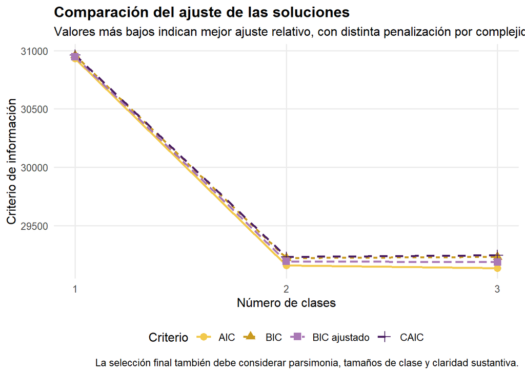

```r
figura_ajuste <- ggplot2::ggplot(
  datos_figura_ajuste,
  ggplot2::aes(
    x = clases,
    y = valor,
    group = criterio,
    color = criterio,
    linetype = criterio,
    shape = criterio
  )
) +
  ggplot2::geom_line(
    linewidth = 0.9
  ) +
  ggplot2::geom_point(
    size = 3
  ) +
  ggplot2::scale_color_manual(
    values = paleta_criterios,
    breaks = names(paleta_criterios),
    limits = names(paleta_criterios),
    drop = FALSE
  ) +
  ggplot2::scale_x_continuous(
    breaks = secuencia_clases
  ) +
  ggplot2::labs(
    title = "Comparación del ajuste de las soluciones",
    subtitle = "Valores más bajos indican mejor ajuste relativo, con distinta penalización por complejidad",
    x = "Número de clases",
    y = "Criterio de información",
    color = "Criterio",
    linetype = "Criterio",
    shape = "Criterio",
    caption = "La selección final también debe considerar parsimonia, tamaños de clase y claridad sustantiva."
  ) +
  ggplot2::theme_minimal(
    base_size = 12
  ) +
  ggplot2::theme(
    panel.grid.minor =
      ggplot2::element_blank(),

    plot.title =
      ggplot2::element_text(
        face = "bold"
      ),

    legend.position =
      "bottom"
  )

figura_ajuste
```

# 17 Diagnóstico de clasificación

**Mostrar código**

```r
datos_figura_clasificacion <- tabla_ajuste |>
  dplyr::filter(
    convergio,
    clases > 1
  ) |>
  dplyr::select(
    clases,
    entropia,
    posterior_maxima_media,
    proporcion_posterior_070,
    proporcion_posterior_080
  ) |>
  tidyr::pivot_longer(
    cols = -clases,
    names_to = "indicador",
    values_to = "valor"
  ) |>
  dplyr::mutate(
    indicador = dplyr::recode(
      indicador,
      "entropia" =
        "Entropía normalizada",

      "posterior_maxima_media" =
        "Probabilidad posterior máxima media",

      "proporcion_posterior_070" =
        "Proporción con posterior ≥ 0,70",

      "proporcion_posterior_080" =
        "Proporción con posterior ≥ 0,80"
    )
  )
```

**Mostrar código**

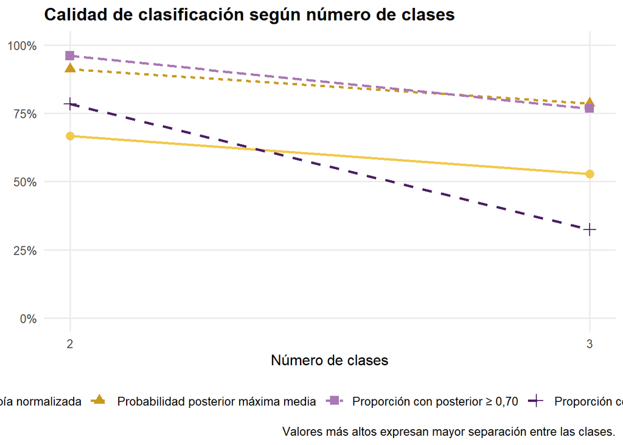

```r
figura_clasificacion <- ggplot2::ggplot(
  datos_figura_clasificacion,
  ggplot2::aes(
    x = clases,
    y = valor,
    group = indicador,
    color = indicador,
    linetype = indicador,
    shape = indicador
  )
) +
  ggplot2::geom_line(
    linewidth = 0.9
  ) +
  ggplot2::geom_point(
    size = 3
  ) +
  ggplot2::scale_color_manual(
    values = paleta_diagnostico,
    breaks = names(paleta_diagnostico),
    limits = names(paleta_diagnostico),
    drop = FALSE
  ) +
  ggplot2::scale_x_continuous(
    breaks = secuencia_clases
  ) +
  ggplot2::scale_y_continuous(
    limits = c(
      0,
      1
    ),
    labels = scales::label_percent(
      accuracy = 1
    )
  ) +
  ggplot2::labs(
    title = "Calidad de clasificación según número de clases",
    x = "Número de clases",
    y = NULL,
    color = NULL,
    linetype = NULL,
    shape = NULL,
    caption = "Valores más altos expresan mayor separación entre las clases."
  ) +
  ggplot2::theme_minimal(
    base_size = 12
  ) +
  ggplot2::theme(
    panel.grid.minor =
      ggplot2::element_blank(),

    plot.title =
      ggplot2::element_text(
        face = "bold"
      ),

    legend.position =
      "bottom"
  )

figura_clasificacion
```

# 18 Selección de la solución principal

El número de clases se fija al comienzo del documento mediante `numero_clases_elegido`. La especificación inicial utiliza tres clases para facilitar el ejercicio pedagógico, pero la decisión debe revisarse a partir de:

- criterios de información;
- entropía;
- tamaño de la clase más pequeña;
- probabilidades posteriores;
- claridad de los perfiles.

**Mostrar código**

```r
nombre_modelo_elegido <- paste0(
  "clases_",
  numero_clases_elegido
)

modelo_elegido <- modelos_lca[[
  nombre_modelo_elegido
]]

if (
  is.null(
    modelo_elegido
  ) ||
    is.null(
      modelo_elegido$posterior
    ) ||
    nrow(
      modelo_elegido$posterior
    ) !=
      nrow(
        base_lca
      )
) {

  stop(
    paste0(
      "La solución elegida de ",
      numero_clases_elegido,
      " clases no fue estimada correctamente o no coincide con la muestra analítica."
    )
  )
}
```

# 19 Extracción de los perfiles de clase

## 19.1 Función para recuperar la probabilidad de inseguridad

La categoría 2 corresponde a la modalidad de inseguridad en cada indicador.

**Mostrar código**

```r
extraer_probabilidades_inseguridad <- function(
    modelo,
    diccionario
) {

  if (
    is.null(
      modelo$probs
    ) ||
      length(
        modelo$probs
      ) == 0
  ) {

    stop(
      "El modelo elegido no contiene probabilidades condicionales."
    )
  }

  variables_probabilidades <- intersect(
    names(
      modelo$probs
    ),
    diccionario$variable_lca
  )

  if (
    length(
      variables_probabilidades
    ) !=
      nrow(
        diccionario
      )
  ) {

    stop(
      paste0(
        "No fue posible reconocer todas las variables en modelo$probs. Variables encontradas: ",
        paste(
          names(
            modelo$probs
          ),
          collapse = ", "
        )
      )
    )
  }

  purrr::map_dfr(
    variables_probabilidades,
    function(
        variable
    ) {

      matriz_probabilidades <-
        modelo$probs[[variable]]

      if (ncol(matriz_probabilidades) < 2) {

        stop(
          paste0(
            "El indicador ",
            variable,
            " no presenta dos categorías en el modelo."
          )
        )
      }

      tibble::tibble(
        variable_lca = variable,
        clase_original =
          seq_len(
            nrow(
              matriz_probabilidades
            )
          ),

        probabilidad_inseguridad =
          matriz_probabilidades[
            ,
            2
          ]
      )
    }
  ) |>
    dplyr::left_join(
      diccionario,
      by = "variable_lca"
    )
}
```

**Mostrar código**

```r
perfiles_originales <- extraer_probabilidades_inseguridad(
  modelo = modelo_elegido,
  diccionario = diccionario_indicadores
)
```

# 20 Ordenamiento sustantivo de las clases

Las etiquetas numéricas producidas por el modelo son arbitrarias. Para hacer comparables las figuras, las clases se ordenan según la probabilidad media de inseguridad en los cuatro indicadores.

**Mostrar código**

```r
orden_clases <- perfiles_originales |>
  dplyr::group_by(
    clase_original
  ) |>
  dplyr::summarise(
    promedio_inseguridad = mean(
      probabilidad_inseguridad
    ),
    .groups = "drop"
  ) |>
  dplyr::arrange(
    promedio_inseguridad
  ) |>
  dplyr::mutate(
    clase_ordenada = dplyr::row_number()
  )
```

## 20.1 Etiquetas de la solución

Para la solución inicial de tres clases se utilizan nombres provisionales. Los nombres deben revisarse después de observar los perfiles.

**Mostrar código**

```r
crear_etiquetas_clase <- function(
    numero_clases
) {

  if (numero_clases == 2L) {

    return(
      c(
        "Relativamente protegida",
        "Inseguridad acumulada"
      )
    )
  }

  if (numero_clases == 3L) {

    return(
      c(
        "Relativamente protegida",
        "Vulnerabilidad parcial",
        "Inseguridad acumulada"
      )
    )
  }

  paste0(
    "Clase ",
    seq_len(
      numero_clases
    )
  )
}
```

**Mostrar código**

```r
etiquetas_clases <- crear_etiquetas_clase(
  numero_clases_elegido
)

paleta_clases <- if (numero_clases_elegido == 2L) {
  c(
    "Relativamente protegida" = color_mostaza,
    "Inseguridad acumulada" = color_morado_oscuro
  )
} else if (numero_clases_elegido == 3L) {
  c(
    "Relativamente protegida" = color_mostaza,
    "Vulnerabilidad parcial" = color_morado_claro,
    "Inseguridad acumulada" = color_morado_oscuro
  )
} else {
  stats::setNames(
    grDevices::colorRampPalette(c(color_mostaza, color_morado_oscuro))(numero_clases_elegido),
    etiquetas_clases
  )
}

escala_color_clases <- function() {
  ggplot2::scale_color_manual(
    values = paleta_clases,
    breaks = names(paleta_clases),
    limits = names(paleta_clases),
    drop = FALSE
  )
}

escala_relleno_clases <- function() {
  ggplot2::scale_fill_manual(
    values = paleta_clases,
    breaks = names(paleta_clases),
    limits = names(paleta_clases),
    drop = FALSE
  )
}

diccionario_clases <- orden_clases |>
  dplyr::mutate(
    clase_etiqueta =
      etiquetas_clases[
        clase_ordenada
      ],

    clase_etiqueta = factor(
      clase_etiqueta,
      levels =
        etiquetas_clases
    )
  )
```

**Mostrar código**

```r
knitr::kable(
  diccionario_clases |>
    dplyr::mutate(
      promedio_inseguridad = round(
        promedio_inseguridad,
        3
      )
    ),
  caption = "Ordenamiento y etiquetado provisional de las clases"
)
```

Ordenamiento y etiquetado provisional de las clases

| clase_original | promedio_inseguridad | clase_ordenada | clase_etiqueta |
| --- | --- | --- | --- |
| 1 | 0.253 | 1 | Relativamente protegida |
| 3 | 0.592 | 2 | Vulnerabilidad parcial |
| 2 | 0.778 | 3 | Inseguridad acumulada |

# 21 Perfiles ordenados

**Mostrar código**

```r
tabla_perfiles_clases <- perfiles_originales |>
  dplyr::left_join(
    diccionario_clases,
    by = "clase_original"
  ) |>
  dplyr::mutate(
    indicador = factor(
      indicador,
      levels = c(
        "Dificultad para llegar a fin de mes",
        "Fragilidad intensa ante pérdida de ingresos",
        "Desprotección financiera en salud",
        "Falta de apoyo monetario"
      )
    )
  ) |>
  dplyr::select(
    clase_original,
    clase_ordenada,
    clase_etiqueta,
    variable_lca,
    indicador,
    probabilidad_inseguridad,
    promedio_inseguridad
  ) |>
  dplyr::arrange(
    clase_ordenada,
    indicador
  )
```

**Mostrar código**

```r
knitr::kable(
  tabla_perfiles_clases |>
    dplyr::mutate(
      probabilidad_inseguridad = round(
        probabilidad_inseguridad,
        3
      ),

      promedio_inseguridad = round(
        promedio_inseguridad,
        3
      )
    ),
  caption = "Probabilidades condicionales de inseguridad según clase"
)
```

Probabilidades condicionales de inseguridad según clase

| clase_original | clase_ordenada | clase_etiqueta | variable_lca | indicador | probabilidad_inseguridad | promedio_inseguridad |
| --- | --- | --- | --- | --- | --- | --- |
| 1 | 1 | Relativamente protegida | fin_mes_lca | Dificultad para llegar a fin de mes | 0.146 | 0.253 |
| 1 | 1 | Relativamente protegida | reservas_lca | Fragilidad intensa ante pérdida de ingresos | 0.339 | 0.253 |
| 1 | 1 | Relativamente protegida | salud_lca | Desprotección financiera en salud | 0.439 | 0.253 |
| 1 | 1 | Relativamente protegida | apoyo_lca | Falta de apoyo monetario | 0.088 | 0.253 |
| 3 | 2 | Vulnerabilidad parcial | fin_mes_lca | Dificultad para llegar a fin de mes | 0.975 | 0.592 |
| 3 | 2 | Vulnerabilidad parcial | reservas_lca | Fragilidad intensa ante pérdida de ingresos | 0.659 | 0.592 |
| 3 | 2 | Vulnerabilidad parcial | salud_lca | Desprotección financiera en salud | 0.682 | 0.592 |
| 3 | 2 | Vulnerabilidad parcial | apoyo_lca | Falta de apoyo monetario | 0.051 | 0.592 |
| 2 | 3 | Inseguridad acumulada | fin_mes_lca | Dificultad para llegar a fin de mes | 0.960 | 0.778 |
| 2 | 3 | Inseguridad acumulada | reservas_lca | Fragilidad intensa ante pérdida de ingresos | 0.905 | 0.778 |
| 2 | 3 | Inseguridad acumulada | salud_lca | Desprotección financiera en salud | 0.932 | 0.778 |
| 2 | 3 | Inseguridad acumulada | apoyo_lca | Falta de apoyo monetario | 0.313 | 0.778 |

# 22 Figura de perfiles

**Mostrar código**

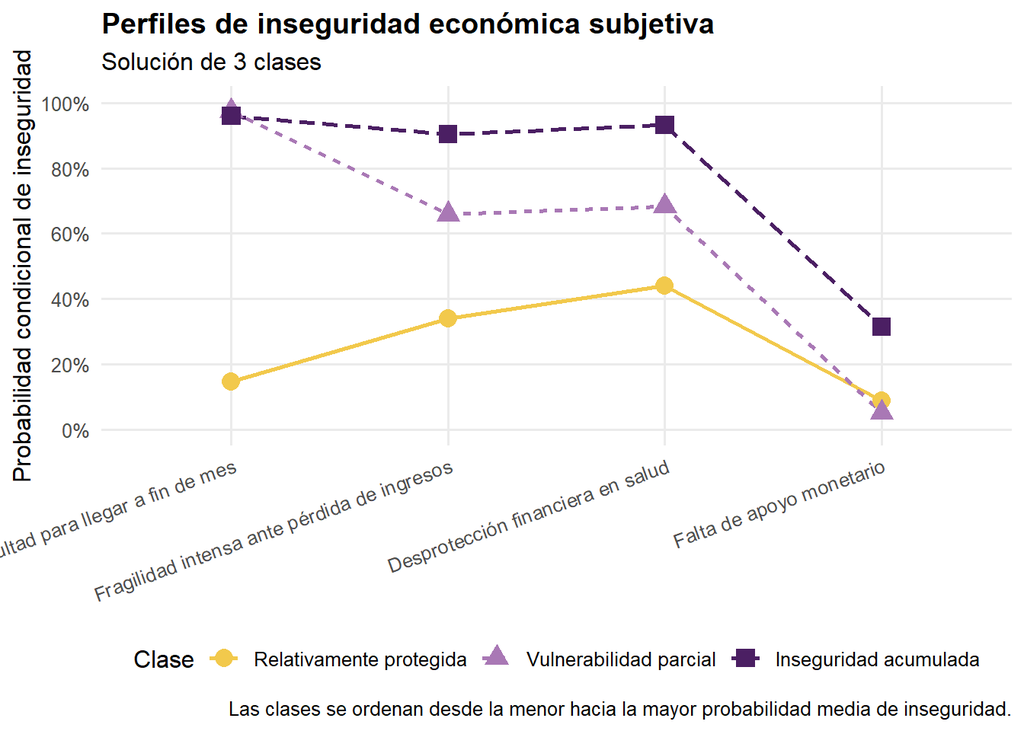

```r
figura_perfiles <- ggplot2::ggplot(
  tabla_perfiles_clases,
  ggplot2::aes(
    x = indicador,
    y = probabilidad_inseguridad,
    group = clase_etiqueta,
    color = clase_etiqueta,
    linetype = clase_etiqueta,
    shape = clase_etiqueta
  )
) +
  ggplot2::geom_line(
    linewidth = 1
  ) +
  ggplot2::geom_point(
    size = 3.6,
    stroke = 1
  ) +
  escala_color_clases() +
  ggplot2::scale_y_continuous(
    limits = c(
      0,
      1
    ),
    breaks = seq(
      0,
      1,
      by = 0.2
    ),
    labels = scales::label_percent(
      accuracy = 1
    )
  ) +
  ggplot2::labs(
    title = "Perfiles de inseguridad económica subjetiva",
    subtitle = paste0(
      "Solución de ",
      numero_clases_elegido,
      " clases"
    ),
    x = NULL,
    y = "Probabilidad condicional de inseguridad",
    color = "Clase",
    linetype = "Clase",
    shape = "Clase",
    caption = "Las clases se ordenan desde la menor hacia la mayor probabilidad media de inseguridad."
  ) +
  ggplot2::theme_minimal(
    base_size = 12
  ) +
  ggplot2::theme(
    panel.grid.minor =
      ggplot2::element_blank(),

    axis.text.x =
      ggplot2::element_text(
        angle = 20,
        hjust = 1
      ),

    plot.title =
      ggplot2::element_text(
        face = "bold"
      ),

    legend.position =
      "bottom"
  )

figura_perfiles
```

# 23 Incorporación de probabilidades posteriores

## 23.1 Asignación modal y probabilidades individuales

**Mostrar código**

```r
posteriores <- as.data.frame(
  modelo_elegido$posterior
) |>
  tibble::as_tibble()

names(
  posteriores
) <- paste0(
  "posterior_clase_original_",
  seq_len(
    ncol(
      posteriores
    )
  )
)
```

**Mostrar código**

```r
base_clasificada <- base_lca |>
  dplyr::mutate(
    clase_original =
      modelo_elegido$predclass,

    posterior_maxima = apply(
      modelo_elegido$posterior,
      1,
      max
    )
  ) |>
  dplyr::left_join(
    diccionario_clases |>
      dplyr::select(
        clase_original,
        clase_ordenada,
        clase_etiqueta
      ),
    by = "clase_original"
  ) |>
  dplyr::bind_cols(
    posteriores
  ) |>
  dplyr::mutate(
    clase_etiqueta = factor(
      as.character(
        clase_etiqueta
      ),
      levels = etiquetas_clases
    )
  )
```

**Mostrar código**

```r
if (
  nrow(
    base_clasificada
  ) !=
    nrow(
      base_lca
    )
) {

  stop(
    "El número de casos clasificados no coincide con la muestra del modelo."
  )
}
```

# 24 Diagnóstico de la solución elegida

## 24.1 Tamaños de clase

**Mostrar código**

```r
tabla_tamanos_clase <- base_clasificada |>
  dplyr::group_by(
    clase_ordenada,
    clase_etiqueta
  ) |>
  dplyr::summarise(
    n = dplyr::n(),

    suma_ponderadores = sum(
      ponderador,
      na.rm = TRUE
    ),

    posterior_maxima_media = mean(
      posterior_maxima
    ),

    proporcion_posterior_070 = mean(
      posterior_maxima >= 0.70
    ),

    proporcion_posterior_080 = mean(
      posterior_maxima >= 0.80
    ),

    .groups = "drop"
  ) |>
  dplyr::mutate(
    porcentaje_no_ponderado = 100 *
      n /
      sum(
        n
      ),

    porcentaje_ponderado = 100 *
      suma_ponderadores /
      sum(
        suma_ponderadores
      )
  ) |>
  dplyr::arrange(
    clase_ordenada
  )
```

**Mostrar código**

```r
knitr::kable(
  tabla_tamanos_clase |>
    dplyr::mutate(
      suma_ponderadores = round(
        suma_ponderadores
      ),

      dplyr::across(
        c(
          posterior_maxima_media,
          proporcion_posterior_070,
          proporcion_posterior_080
        ),
        ~ round(
          .x,
          3
        )
      ),

      dplyr::across(
        c(
          porcentaje_no_ponderado,
          porcentaje_ponderado
        ),
        ~ round(
          .x,
          1
        )
      )
    ),
  caption = "Tamaño y calidad de clasificación de las clases elegidas"
)
```

Tamaño y calidad de clasificación de las clases elegidas

| clase_ordenada | clase_etiqueta | n | suma_ponderadores | posterior_maxima_media | proporcion_posterior_070 | proporcion_posterior_080 | porcentaje_no_ponderado | porcentaje_ponderado |
| --- | --- | --- | --- | --- | --- | --- | --- | --- |
| 1 | Relativamente protegida | 1250 | 2001086 | 0.860 | 0.782 | 0.782 | 16.6 | 17.6 |
| 2 | Vulnerabilidad parcial | 1453 | 2299268 | 0.571 | 0.000 | 0.000 | 19.3 | 20.3 |
| 3 | Inseguridad acumulada | 4836 | 7041218 | 0.831 | 0.995 | 0.304 | 64.1 | 62.1 |

## 24.2 Figura de prevalencia de las clases

**Mostrar código**

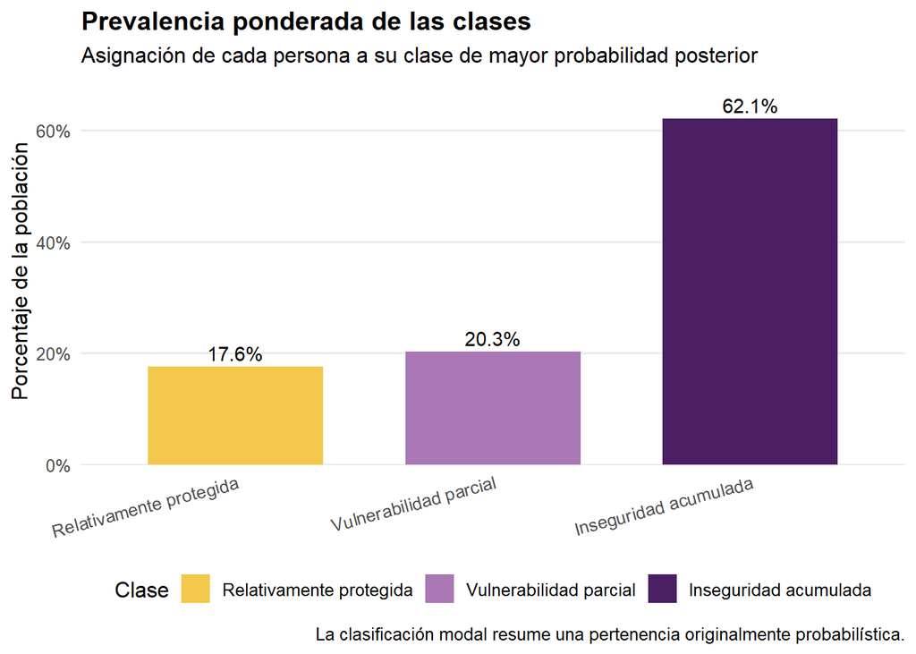

```r
figura_prevalencia_clases <- tabla_tamanos_clase |>
  ggplot2::ggplot(
    ggplot2::aes(
      x = clase_etiqueta,
      y = porcentaje_ponderado,
      fill = clase_etiqueta
    )
  ) +
  ggplot2::geom_col(
    width = 0.68
  ) +
  escala_relleno_clases() +
  ggplot2::geom_text(
    ggplot2::aes(
      label = paste0(
        round(
          porcentaje_ponderado,
          1
        ),
        "%"
      )
    ),
    vjust = -0.4,
    size = 3.8
  ) +
  ggplot2::scale_y_continuous(
    labels = scales::label_percent(
      scale = 1
    ),
    expand = ggplot2::expansion(
      mult = c(
        0,
        0.12
      )
    )
  ) +
  ggplot2::labs(
    title = "Prevalencia ponderada de las clases",
    subtitle = "Asignación de cada persona a su clase de mayor probabilidad posterior",
    x = NULL,
    y = "Porcentaje de la población",
    fill = "Clase",
    caption = "La clasificación modal resume una pertenencia originalmente probabilística."
  ) +
  ggplot2::theme_minimal(
    base_size = 12
  ) +
  ggplot2::theme(
    panel.grid.minor =
      ggplot2::element_blank(),

    panel.grid.major.x =
      ggplot2::element_blank(),

    axis.text.x =
      ggplot2::element_text(
        angle = 15,
        hjust = 1
      ),

    plot.title =
      ggplot2::element_text(
        face = "bold"
      ),

    legend.position =
      "bottom"
  )

figura_prevalencia_clases
```

# 25 Funciones para distribuciones externas

## 25.1 Distribución ponderada de clases dentro de cada grupo

**Mostrar código**

```r
calcular_distribucion_clases <- function(
    datos,
    variable_grupo,
    etiqueta_variable
) {

  datos |>
    dplyr::filter(
      !is.na(
        .data[[variable_grupo]]
      ),
      !is.na(
        clase_etiqueta
      ),
      !is.na(
        ponderador
      ),
      ponderador > 0
    ) |>
    dplyr::group_by(
      grupo = .data[[variable_grupo]],
      clase_etiqueta
    ) |>
    dplyr::summarise(
      n = dplyr::n(),

      frecuencia_ponderada = sum(
        ponderador
      ),

      .groups = "drop"
    ) |>
    dplyr::group_by(
      grupo
    ) |>
    dplyr::mutate(
      porcentaje_clase_dentro_grupo = 100 *
        frecuencia_ponderada /
        sum(
          frecuencia_ponderada
        )
    ) |>
    dplyr::ungroup() |>
    dplyr::mutate(
      color_texto = dplyr::case_when(
        as.character(clase_etiqueta) == "Inseguridad acumulada" ~ "white",
        TRUE ~ color_gris_oscuro
      ),
      variable_grupo = variable_grupo,
      dimension = etiqueta_variable,
      .before = 1
    )
}
```

## 25.2 Distribución de características dentro de cada clase

**Mostrar código**

```r
calcular_composicion_clases <- function(
    datos,
    variable_grupo,
    etiqueta_variable
) {

  datos |>
    dplyr::filter(
      !is.na(
        .data[[variable_grupo]]
      ),
      !is.na(
        clase_etiqueta
      ),
      !is.na(
        ponderador
      ),
      ponderador > 0
    ) |>
    dplyr::group_by(
      clase_etiqueta,
      grupo = .data[[variable_grupo]]
    ) |>
    dplyr::summarise(
      n = dplyr::n(),

      frecuencia_ponderada = sum(
        ponderador
      ),

      .groups = "drop"
    ) |>
    dplyr::group_by(
      clase_etiqueta
    ) |>
    dplyr::mutate(
      porcentaje_grupo_dentro_clase = 100 *
        frecuencia_ponderada /
        sum(
          frecuencia_ponderada
        )
    ) |>
    dplyr::ungroup() |>
    dplyr::mutate(
      variable_grupo = variable_grupo,
      dimension = etiqueta_variable,
      .before = 1
    )
}
```

# 26 Distribución por género

**Mostrar código**

```r
tabla_clases_genero <- calcular_distribucion_clases(
  datos = base_clasificada,
  variable_grupo = "genero",
  etiqueta_variable = "Género"
)
```

**Mostrar código**

```r
knitr::kable(
  tabla_clases_genero |>
    dplyr::mutate(
      frecuencia_ponderada = round(
        frecuencia_ponderada
      ),

      porcentaje_clase_dentro_grupo = round(
        porcentaje_clase_dentro_grupo,
        1
      )
    ),
  caption = "Distribución ponderada de clases dentro de cada género"
)
```

Distribución ponderada de clases dentro de cada género

| color_texto | variable_grupo | dimension | grupo | clase_etiqueta | n | frecuencia_ponderada | porcentaje_clase_dentro_grupo |
| --- | --- | --- | --- | --- | --- | --- | --- |
| #4D4D4D | genero | Género | Mujeres | Relativamente protegida | 640 | 872866 | 15.2 |
| #4D4D4D | genero | Género | Mujeres | Vulnerabilidad parcial | 784 | 1075331 | 18.7 |
| white | genero | Género | Mujeres | Inseguridad acumulada | 3053 | 3788742 | 66.0 |
| #4D4D4D | genero | Género | Hombres | Relativamente protegida | 610 | 1128220 | 20.1 |
| #4D4D4D | genero | Género | Hombres | Vulnerabilidad parcial | 669 | 1223937 | 21.8 |
| white | genero | Género | Hombres | Inseguridad acumulada | 1783 | 3252476 | 58.0 |

**Mostrar código**

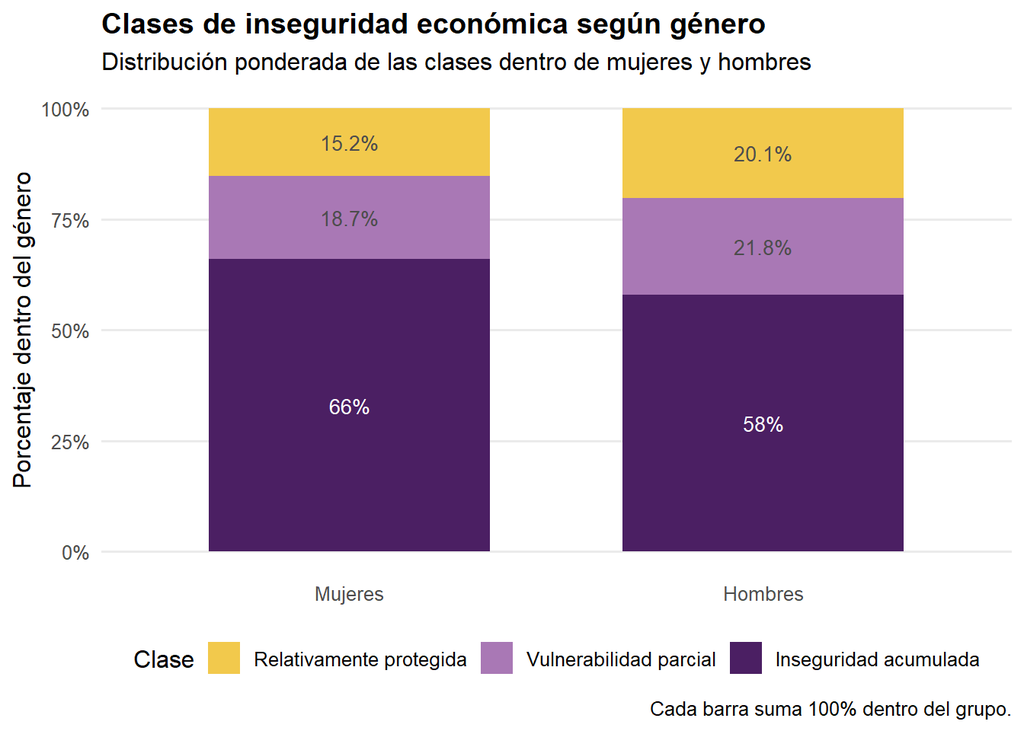

```r
figura_genero <- ggplot2::ggplot(
  tabla_clases_genero,
  ggplot2::aes(
    x = grupo,
    y = porcentaje_clase_dentro_grupo,
    fill = clase_etiqueta
  )
) +
  ggplot2::geom_col(
    position = "stack",
    width = 0.68
  ) +
  ggplot2::geom_text(
    ggplot2::aes(
      label = dplyr::if_else(
        porcentaje_clase_dentro_grupo >= 7,
        paste0(
          round(
            porcentaje_clase_dentro_grupo,
            1
          ),
          "%"
        ),
        ""
      ),
      color = color_texto
    ),
    position = ggplot2::position_stack(
      vjust = 0.5
    ),
    size = 3.5,
    show.legend = FALSE
  ) +
  ggplot2::scale_color_identity() +
  escala_relleno_clases() +
  ggplot2::scale_y_continuous(
    labels = scales::label_percent(
      scale = 1
    )
  ) +
  ggplot2::labs(
    title = "Clases de inseguridad económica según género",
    subtitle = "Distribución ponderada de las clases dentro de mujeres y hombres",
    x = NULL,
    y = "Porcentaje dentro del género",
    fill = "Clase",
    caption = "Cada barra suma 100% dentro del grupo."
  ) +
  ggplot2::theme_minimal(
    base_size = 12
  ) +
  ggplot2::theme(
    panel.grid.minor =
      ggplot2::element_blank(),

    panel.grid.major.x =
      ggplot2::element_blank(),

    plot.title =
      ggplot2::element_text(
        face = "bold"
      ),

    legend.position =
      "bottom"
  )

figura_genero
```

# 27 Distribución por grupos sexo-etarios

**Mostrar código**

```r
tabla_clases_sexo_edad <- calcular_distribucion_clases(
  datos = base_clasificada,
  variable_grupo = "grupo_sexo_edad",
  etiqueta_variable = "Grupo sexo-etario"
)
```

**Mostrar código**

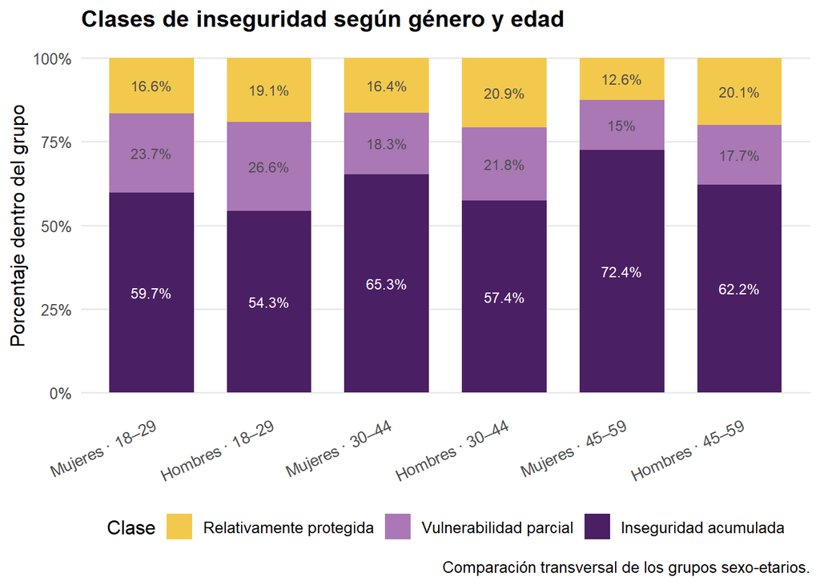

```r
figura_sexo_edad <- ggplot2::ggplot(
  tabla_clases_sexo_edad,
  ggplot2::aes(
    x = grupo,
    y = porcentaje_clase_dentro_grupo,
    fill = clase_etiqueta
  )
) +
  ggplot2::geom_col(
    width = 0.72
  ) +
  ggplot2::geom_text(
    ggplot2::aes(
      label = dplyr::if_else(
        porcentaje_clase_dentro_grupo >= 8,
        paste0(
          round(
            porcentaje_clase_dentro_grupo,
            1
          ),
          "%"
        ),
        ""
      ),
      color = color_texto
    ),
    position = ggplot2::position_stack(
      vjust = 0.5
    ),
    size = 3.1,
    show.legend = FALSE
  ) +
  ggplot2::scale_color_identity() +
  escala_relleno_clases() +
  ggplot2::scale_y_continuous(
    labels = scales::label_percent(
      scale = 1
    )
  ) +
  ggplot2::labs(
    title = "Clases de inseguridad según género y edad",
    x = NULL,
    y = "Porcentaje dentro del grupo",
    fill = "Clase",
    caption = "Comparación transversal de los grupos sexo-etarios."
  ) +
  ggplot2::theme_minimal(
    base_size = 12
  ) +
  ggplot2::theme(
    panel.grid.minor =
      ggplot2::element_blank(),

    panel.grid.major.x =
      ggplot2::element_blank(),

    axis.text.x =
      ggplot2::element_text(
        angle = 25,
        hjust = 1
      ),

    plot.title =
      ggplot2::element_text(
        face = "bold"
      ),

    legend.position =
      "bottom"
  )

figura_sexo_edad
```

# 28 Distribución por posición de ingreso

**Mostrar código**

```r
tabla_clases_ingreso <- calcular_distribucion_clases(
  datos = base_clasificada,
  variable_grupo = "posicion_ingreso_3",
  etiqueta_variable = "Posición de ingreso"
)
```

**Mostrar código**

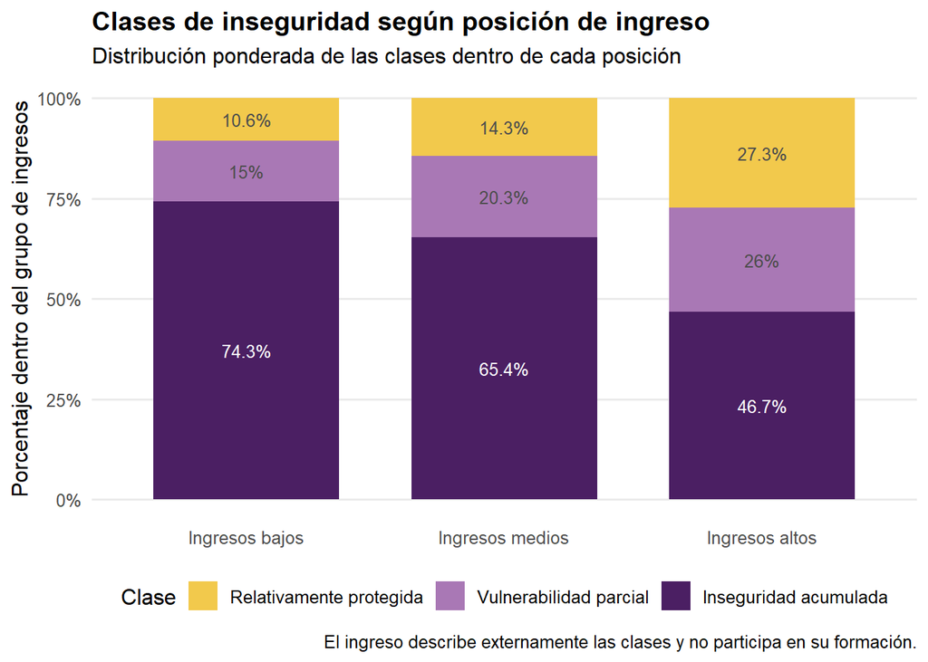

```r
figura_ingreso <- ggplot2::ggplot(
  tabla_clases_ingreso,
  ggplot2::aes(
    x = grupo,
    y = porcentaje_clase_dentro_grupo,
    fill = clase_etiqueta
  )
) +
  ggplot2::geom_col(
    width = 0.72
  ) +
  ggplot2::geom_text(
    ggplot2::aes(
      label = dplyr::if_else(
        porcentaje_clase_dentro_grupo >= 7,
        paste0(
          round(
            porcentaje_clase_dentro_grupo,
            1
          ),
          "%"
        ),
        ""
      ),
      color = color_texto
    ),
    position = ggplot2::position_stack(
      vjust = 0.5
    ),
    size = 3.4,
    show.legend = FALSE
  ) +
  ggplot2::scale_color_identity() +
  escala_relleno_clases() +
  ggplot2::scale_y_continuous(
    labels = scales::label_percent(
      scale = 1
    )
  ) +
  ggplot2::labs(
    title = "Clases de inseguridad según posición de ingreso",
    subtitle = "Distribución ponderada de las clases dentro de cada posición",
    x = NULL,
    y = "Porcentaje dentro del grupo de ingresos",
    fill = "Clase",
    caption = "El ingreso describe externamente las clases y no participa en su formación."
  ) +
  ggplot2::theme_minimal(
    base_size = 12
  ) +
  ggplot2::theme(
    panel.grid.minor =
      ggplot2::element_blank(),

    panel.grid.major.x =
      ggplot2::element_blank(),

    plot.title =
      ggplot2::element_text(
        face = "bold"
      ),

    legend.position =
      "bottom"
  )

figura_ingreso
```

# 29 Distribución por nivel educacional

**Mostrar código**

```r
tabla_clases_educacion <- calcular_distribucion_clases(
  datos = base_clasificada,
  variable_grupo = "nivel_educacional_3",
  etiqueta_variable = "Nivel educacional"
)
```

**Mostrar código**

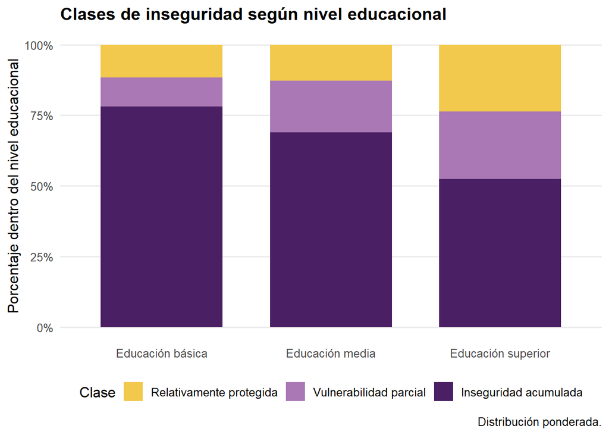

```r
figura_educacion <- ggplot2::ggplot(
  tabla_clases_educacion,
  ggplot2::aes(
    x = grupo,
    y = porcentaje_clase_dentro_grupo,
    fill = clase_etiqueta
  )
) +
  ggplot2::geom_col(
    width = 0.72
  ) +
  escala_relleno_clases() +
  ggplot2::scale_y_continuous(
    labels = scales::label_percent(
      scale = 1
    )
  ) +
  ggplot2::labs(
    title = "Clases de inseguridad según nivel educacional",
    x = NULL,
    y = "Porcentaje dentro del nivel educacional",
    fill = "Clase",
    caption = "Distribución ponderada."
  ) +
  ggplot2::theme_minimal(
    base_size = 12
  ) +
  ggplot2::theme(
    panel.grid.minor =
      ggplot2::element_blank(),

    panel.grid.major.x =
      ggplot2::element_blank(),

    plot.title =
      ggplot2::element_text(
        face = "bold"
      ),

    legend.position =
      "bottom"
  )

figura_educacion
```

# 30 Distribución por tenencia de vivienda

**Mostrar código**

```r
tabla_clases_tenencia <- calcular_distribucion_clases(
  datos = base_clasificada,
  variable_grupo = "tenencia_vivienda_3",
  etiqueta_variable = "Tenencia de vivienda"
)
```

**Mostrar código**

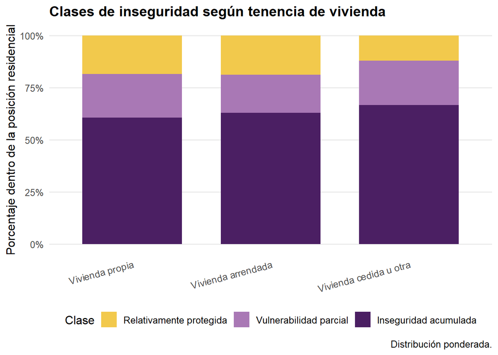

```r
figura_tenencia <- ggplot2::ggplot(
  tabla_clases_tenencia,
  ggplot2::aes(
    x = grupo,
    y = porcentaje_clase_dentro_grupo,
    fill = clase_etiqueta
  )
) +
  ggplot2::geom_col(
    width = 0.72
  ) +
  escala_relleno_clases() +
  ggplot2::scale_y_continuous(
    labels = scales::label_percent(
      scale = 1
    )
  ) +
  ggplot2::labs(
    title = "Clases de inseguridad según tenencia de vivienda",
    x = NULL,
    y = "Porcentaje dentro de la posición residencial",
    fill = "Clase",
    caption = "Distribución ponderada."
  ) +
  ggplot2::theme_minimal(
    base_size = 12
  ) +
  ggplot2::theme(
    panel.grid.minor =
      ggplot2::element_blank(),

    panel.grid.major.x =
      ggplot2::element_blank(),

    axis.text.x =
      ggplot2::element_text(
        angle = 15,
        hjust = 1
      ),

    plot.title =
      ggplot2::element_text(
        face = "bold"
      ),

    legend.position =
      "bottom"
  )

figura_tenencia
```

# 31 Distribución por condición de actividad

**Mostrar código**

```r
tabla_clases_actividad <- calcular_distribucion_clases(
  datos = base_clasificada,
  variable_grupo = "condicion_actividad",
  etiqueta_variable = "Condición de actividad"
)
```

**Mostrar código**

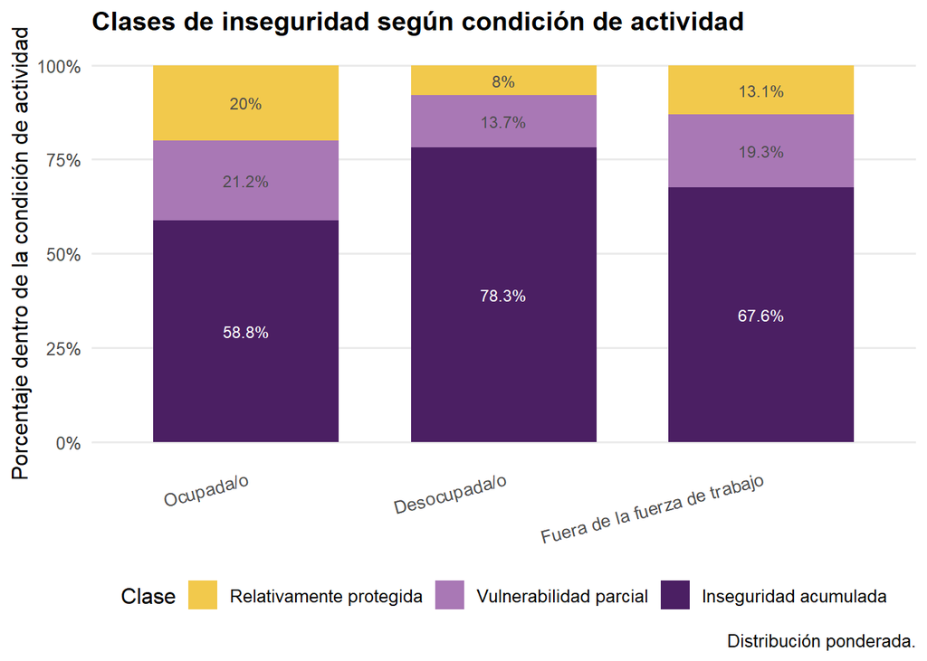

```r
figura_actividad <- ggplot2::ggplot(
  tabla_clases_actividad,
  ggplot2::aes(
    x = grupo,
    y = porcentaje_clase_dentro_grupo,
    fill = clase_etiqueta
  )
) +
  ggplot2::geom_col(
    width = 0.72
  ) +
  ggplot2::geom_text(
    ggplot2::aes(
      label = dplyr::if_else(
        porcentaje_clase_dentro_grupo >= 7,
        paste0(
          round(
            porcentaje_clase_dentro_grupo,
            1
          ),
          "%"
        ),
        ""
      ),
      color = color_texto
    ),
    position = ggplot2::position_stack(
      vjust = 0.5
    ),
    size = 3.2,
    show.legend = FALSE
  ) +
  ggplot2::scale_color_identity() +
  escala_relleno_clases() +
  ggplot2::scale_y_continuous(
    labels = scales::label_percent(
      scale = 1
    )
  ) +
  ggplot2::labs(
    title = "Clases de inseguridad según condición de actividad",
    x = NULL,
    y = "Porcentaje dentro de la condición de actividad",
    fill = "Clase",
    caption = "Distribución ponderada."
  ) +
  ggplot2::theme_minimal(
    base_size = 12
  ) +
  ggplot2::theme(
    panel.grid.minor =
      ggplot2::element_blank(),

    panel.grid.major.x =
      ggplot2::element_blank(),

    axis.text.x =
      ggplot2::element_text(
        angle = 15,
        hjust = 1
      ),

    plot.title =
      ggplot2::element_text(
        face = "bold"
      ),

    legend.position =
      "bottom"
  )

figura_actividad
```

# 32 Distribución por género y estructura parental

**Mostrar código**

```r
tabla_clases_familias <- calcular_distribucion_clases(
  datos = base_clasificada,
  variable_grupo =
    "grupo_genero_estructura_menores",
  etiqueta_variable =
    "Género y estructura parental"
)
```

**Mostrar código**

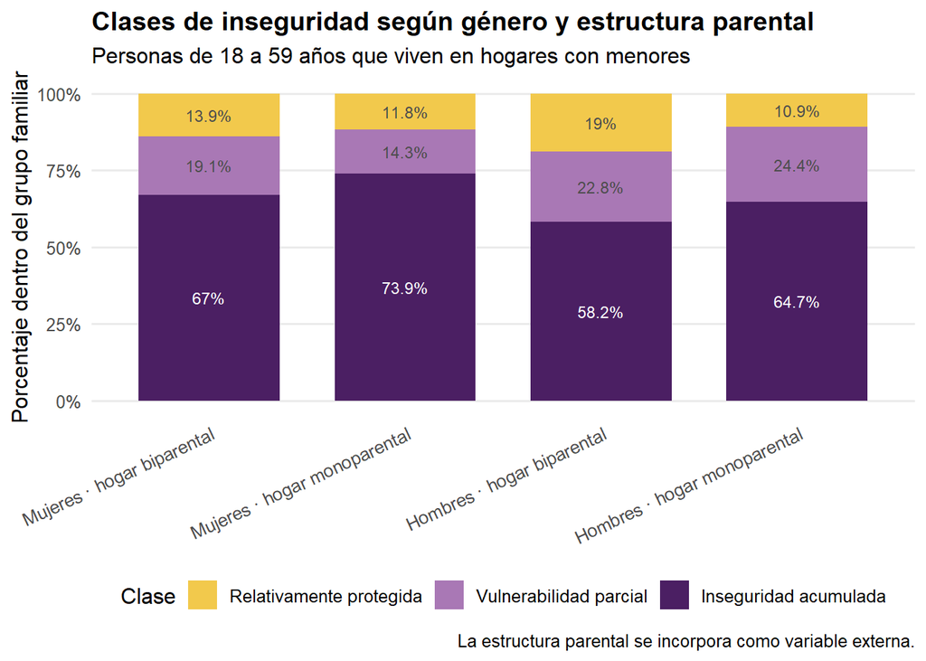

```r
figura_familias <- ggplot2::ggplot(
  tabla_clases_familias,
  ggplot2::aes(
    x = grupo,
    y = porcentaje_clase_dentro_grupo,
    fill = clase_etiqueta
  )
) +
  ggplot2::geom_col(
    width = 0.72
  ) +
  ggplot2::geom_text(
    ggplot2::aes(
      label = dplyr::if_else(
        porcentaje_clase_dentro_grupo >= 7,
        paste0(
          round(
            porcentaje_clase_dentro_grupo,
            1
          ),
          "%"
        ),
        ""
      ),
      color = color_texto
    ),
    position = ggplot2::position_stack(
      vjust = 0.5
    ),
    size = 3.1,
    show.legend = FALSE
  ) +
  ggplot2::scale_color_identity() +
  escala_relleno_clases() +
  ggplot2::scale_y_continuous(
    labels = scales::label_percent(
      scale = 1
    )
  ) +
  ggplot2::labs(
    title = "Clases de inseguridad según género y estructura parental",
    subtitle = "Personas de 18 a 59 años que viven en hogares con menores",
    x = NULL,
    y = "Porcentaje dentro del grupo familiar",
    fill = "Clase",
    caption = "La estructura parental se incorpora como variable externa."
  ) +
  ggplot2::theme_minimal(
    base_size = 12
  ) +
  ggplot2::theme(
    panel.grid.minor =
      ggplot2::element_blank(),

    panel.grid.major.x =
      ggplot2::element_blank(),

    axis.text.x =
      ggplot2::element_text(
        angle = 25,
        hjust = 1
      ),

    plot.title =
      ggplot2::element_text(
        face = "bold"
      ),

    legend.position =
      "bottom"
  )

figura_familias
```

# 33 Variables económicas complementarias

## 33.1 Cambio reciente del ingreso

**Mostrar código**

```r
tabla_clases_cambio_ingreso <- calcular_distribucion_clases(
  datos = base_clasificada,
  variable_grupo = "cambio_ingreso",
  etiqueta_variable = "Cambio reciente del ingreso"
)
```

## 33.2 Presencia de deuda

**Mostrar código**

```r
tabla_clases_deuda <- calcular_distribucion_clases(
  datos = base_clasificada,
  variable_grupo = "deuda",
  etiqueta_variable = "Presencia de deuda"
)
```

**Mostrar código**

```r
tabla_variables_complementarias <- dplyr::bind_rows(
  tabla_clases_cambio_ingreso,
  tabla_clases_deuda
)
```

**Mostrar código**

```r
knitr::kable(
  tabla_variables_complementarias |>
    dplyr::mutate(
      frecuencia_ponderada = round(
        frecuencia_ponderada
      ),

      porcentaje_clase_dentro_grupo = round(
        porcentaje_clase_dentro_grupo,
        1
      )
    ),
  caption = "Distribución de clases según condiciones económicas complementarias"
)
```

Distribución de clases según condiciones económicas complementarias

| color_texto | variable_grupo | dimension | grupo | clase_etiqueta | n | frecuencia_ponderada | porcentaje_clase_dentro_grupo |
| --- | --- | --- | --- | --- | --- | --- | --- |
| #4D4D4D | cambio_ingreso | Cambio reciente del ingreso | Ingreso estable o aumentado | Relativamente protegida | 1099 | 1763942 | 23.5 |
| #4D4D4D | cambio_ingreso | Cambio reciente del ingreso | Ingreso estable o aumentado | Vulnerabilidad parcial | 1075 | 1667422 | 22.2 |
| white | cambio_ingreso | Cambio reciente del ingreso | Ingreso estable o aumentado | Inseguridad acumulada | 2805 | 4078532 | 54.3 |
| #4D4D4D | cambio_ingreso | Cambio reciente del ingreso | Ingreso disminuyó | Relativamente protegida | 141 | 206362 | 5.5 |
| #4D4D4D | cambio_ingreso | Cambio reciente del ingreso | Ingreso disminuyó | Vulnerabilidad parcial | 371 | 618763 | 16.5 |
| white | cambio_ingreso | Cambio reciente del ingreso | Ingreso disminuyó | Inseguridad acumulada | 1997 | 2918932 | 78.0 |
| #4D4D4D | deuda | Presencia de deuda | Sin deuda | Relativamente protegida | 742 | 1199735 | 20.7 |
| #4D4D4D | deuda | Presencia de deuda | Sin deuda | Vulnerabilidad parcial | 799 | 1244734 | 21.4 |
| white | deuda | Presencia de deuda | Sin deuda | Inseguridad acumulada | 2425 | 3358821 | 57.9 |
| #4D4D4D | deuda | Presencia de deuda | Con deuda | Relativamente protegida | 508 | 801351 | 14.5 |
| #4D4D4D | deuda | Presencia de deuda | Con deuda | Vulnerabilidad parcial | 654 | 1054534 | 19.1 |
| white | deuda | Presencia de deuda | Con deuda | Inseguridad acumulada | 2408 | 3671146 | 66.4 |

# 34 Composición social de las clases

Además de preguntar qué clase predomina dentro de cada grupo, resulta útil observar quiénes componen cada clase.

**Mostrar código**

```r
tabla_composicion_genero <- calcular_composicion_clases(
  datos = base_clasificada,
  variable_grupo = "genero",
  etiqueta_variable = "Género"
)

tabla_composicion_ingreso <- calcular_composicion_clases(
  datos = base_clasificada,
  variable_grupo = "posicion_ingreso_3",
  etiqueta_variable = "Posición de ingreso"
)

tabla_composicion_educacion <- calcular_composicion_clases(
  datos = base_clasificada,
  variable_grupo = "nivel_educacional_3",
  etiqueta_variable = "Nivel educacional"
)

tabla_composicion_tenencia <- calcular_composicion_clases(
  datos = base_clasificada,
  variable_grupo = "tenencia_vivienda_3",
  etiqueta_variable = "Tenencia de vivienda"
)

tabla_composicion_actividad <- calcular_composicion_clases(
  datos = base_clasificada,
  variable_grupo = "condicion_actividad",
  etiqueta_variable = "Condición de actividad"
)

tabla_composicion_social <- dplyr::bind_rows(
  tabla_composicion_genero,
  tabla_composicion_ingreso,
  tabla_composicion_educacion,
  tabla_composicion_tenencia,
  tabla_composicion_actividad
)
```

# 35 Resumen de la solución

**Mostrar código**

```r
resumen_solucion_elegida <- tabla_ajuste |>
  dplyr::filter(
    clases ==
      numero_clases_elegido
  ) |>
  dplyr::mutate(
    descripcion = paste0(
      "Solución principal de ",
      numero_clases_elegido,
      " clases"
    ),
    .before = 1
  )
```

**Mostrar código**

```r
knitr::kable(
  resumen_solucion_elegida |>
    dplyr::mutate(
      dplyr::across(
        where(
          is.numeric
        ),
        ~ round(
          .x,
          3
        )
      )
    ),
  caption = "Resumen del ajuste y la clasificación de la solución elegida"
)
```

Resumen del ajuste y la clasificación de la solución elegida

| descripcion | clases | convergio | log_verosimilitud | parametros | AIC | BIC | CAIC | BIC_ajustado | G_cuadrado | chi_cuadrado | grados_libertad_residuales | entropia | posterior_maxima_media | proporcion_posterior_070 | proporcion_posterior_080 | clase_minima_n | clase_minima_porcentaje | iteraciones |
| --- | --- | --- | --- | --- | --- | --- | --- | --- | --- | --- | --- | --- | --- | --- | --- | --- | --- | --- |
| Solución principal de 3 clases | 3 | TRUE | -14553.24 | 14 | 29134.49 | 29231.48 | 29245.48 | 29186.99 | 0.496 | 0.509 | 1 | 0.528 | 0.786 | 0.768 | 0.325 | 1250 | 16.58 | 2919 |

# 36 Exportación de figuras

**Mostrar código**

```r
figuras_exportar <- list(
  "06_comparacion_ajuste" =
    figura_ajuste,

  "06_calidad_clasificacion" =
    figura_clasificacion,

  "06_perfiles_clases" =
    figura_perfiles,

  "06_prevalencia_clases" =
    figura_prevalencia_clases,

  "06_clases_segun_genero" =
    figura_genero,

  "06_clases_segun_sexo_edad" =
    figura_sexo_edad,

  "06_clases_segun_ingreso" =
    figura_ingreso,

  "06_clases_segun_educacion" =
    figura_educacion,

  "06_clases_segun_tenencia" =
    figura_tenencia,

  "06_clases_segun_actividad" =
    figura_actividad,

  "06_clases_segun_estructura_parental" =
    figura_familias
)
```

**Mostrar código**

```r
for (
  nombre_figura in
  names(
    figuras_exportar
  )
) {

  grafico_actual <-
    figuras_exportar[[nombre_figura]]

  ggplot2::ggsave(
    filename = file.path(
      ruta_figuras,
      paste0(
        nombre_figura,
        ".png"
      )
    ),
    plot = grafico_actual,
    width = 11,
    height = 7.5,
    units = "in",
    dpi = 300
  )

  ggplot2::ggsave(
    filename = file.path(
      ruta_figuras,
      paste0(
        nombre_figura,
        ".svg"
      )
    ),
    plot = grafico_actual,
    width = 11,
    height = 7.5,
    units = "in"
  )
}
```

# 37 Exportación de tablas CSV

**Mostrar código**

```r
tablas_csv <- list(
  "06_cobertura_indicadores.csv" =
    tabla_cobertura_indicadores,

  "06_revision_indicadores.csv" =
    tabla_revision_indicadores,

  "06_revision_variables_externas.csv" =
    tabla_revision_variables_externas,

  "06_muestra_analitica.csv" =
    tabla_muestra,

  "06_prevalencias_indicadores.csv" =
    tabla_prevalencias_indicadores,

  "06_comparacion_ajuste.csv" =
    tabla_ajuste,

  "06_diccionario_clases.csv" =
    diccionario_clases,

  "06_perfiles_clases.csv" =
    tabla_perfiles_clases,

  "06_tamanos_clases.csv" =
    tabla_tamanos_clase,

  "06_clases_segun_genero.csv" =
    tabla_clases_genero,

  "06_clases_segun_sexo_edad.csv" =
    tabla_clases_sexo_edad,

  "06_clases_segun_ingreso.csv" =
    tabla_clases_ingreso,

  "06_clases_segun_educacion.csv" =
    tabla_clases_educacion,

  "06_clases_segun_tenencia.csv" =
    tabla_clases_tenencia,

  "06_clases_segun_actividad.csv" =
    tabla_clases_actividad,

  "06_clases_segun_familias.csv" =
    tabla_clases_familias,

  "06_variables_complementarias.csv" =
    tabla_variables_complementarias,

  "06_composicion_social_clases.csv" =
    tabla_composicion_social,

  "06_resumen_solucion_elegida.csv" =
    resumen_solucion_elegida
)
```

**Mostrar código**

```r
purrr::iwalk(
  tablas_csv,
  function(
      tabla,
      nombre_archivo
  ) {

    readr::write_csv(
      tabla,
      file.path(
        ruta_tablas,
        nombre_archivo
      ),
      na = ""
    )
  }
)
```

# 38 Libro Excel consolidado

**Mostrar código**

```r
archivo_excel <- file.path(
  ruta_tablas,
  "06_clases_latentes_inseguridad_subjetiva.xlsx"
)

tablas_excel <- list(
  "Muestra" =
    tabla_muestra,

  "Cobertura indicadores" =
    tabla_cobertura_indicadores,

  "Revisión indicadores" =
    tabla_revision_indicadores,

  "Variables externas" =
    tabla_revision_variables_externas,

  "Prevalencias" =
    tabla_prevalencias_indicadores,

  "Comparación ajuste" =
    tabla_ajuste,

  "Diccionario clases" =
    diccionario_clases,

  "Perfiles clases" =
    tabla_perfiles_clases,

  "Tamaños clases" =
    tabla_tamanos_clase,

  "Clases por género" =
    tabla_clases_genero,

  "Clases por sexo edad" =
    tabla_clases_sexo_edad,

  "Clases por ingreso" =
    tabla_clases_ingreso,

  "Clases por educación" =
    tabla_clases_educacion,

  "Clases por tenencia" =
    tabla_clases_tenencia,

  "Clases por actividad" =
    tabla_clases_actividad,

  "Clases por familias" =
    tabla_clases_familias,

  "Complementarias" =
    tabla_variables_complementarias,

  "Composición social" =
    tabla_composicion_social,

  "Resumen solución" =
    resumen_solucion_elegida
)
```

**Mostrar código**

```r
libro_salida <- openxlsx::createWorkbook()

estilo_encabezado <- openxlsx::createStyle(
  textDecoration = "bold",
  halign = "center",
  valign = "center",
  wrapText = TRUE
)

for (
  nombre_hoja in
  names(
    tablas_excel
  )
) {

  tabla_actual <-
    tablas_excel[[nombre_hoja]]

  nombre_hoja_seguro <- substr(
    nombre_hoja,
    1,
    31
  )

  openxlsx::addWorksheet(
    libro_salida,
    nombre_hoja_seguro
  )

  openxlsx::writeDataTable(
    libro_salida,
    sheet = nombre_hoja_seguro,
    x = tabla_actual
  )

  openxlsx::freezePane(
    libro_salida,
    sheet = nombre_hoja_seguro,
    firstRow = TRUE
  )

  if (
    ncol(
      tabla_actual
    ) > 0
  ) {

    openxlsx::addStyle(
      libro_salida,
      sheet = nombre_hoja_seguro,
      style = estilo_encabezado,
      rows = 1,
      cols = seq_len(
        ncol(
          tabla_actual
        )
      ),
      gridExpand = TRUE
    )

    openxlsx::setColWidths(
      libro_salida,
      sheet = nombre_hoja_seguro,
      cols = seq_len(
        ncol(
          tabla_actual
        )
      ),
      widths = "auto"
    )
  }
}

openxlsx::saveWorkbook(
  libro_salida,
  file = archivo_excel,
  overwrite = TRUE
)
```

# 39 Exportación de objetos reutilizables

**Mostrar código**

```r
saveRDS(
  modelos_lca,
  file.path(
    ruta_objetos,
    "06_modelos_enumeracion_lca.rds"
  )
)

saveRDS(
  modelo_elegido,
  file.path(
    ruta_objetos,
    "06_modelo_lca_elegido.rds"
  )
)

saveRDS(
  base_clasificada,
  file.path(
    ruta_objetos,
    "06_base_con_clases_y_posteriores.rds"
  )
)

saveRDS(
  tabla_ajuste,
  file.path(
    ruta_objetos,
    "06_tabla_ajuste_lca.rds"
  )
)

saveRDS(
  tabla_perfiles_clases,
  file.path(
    ruta_objetos,
    "06_perfiles_clases.rds"
  )
)

saveRDS(
  diccionario_clases,
  file.path(
    ruta_objetos,
    "06_diccionario_clases.rds"
  )
)
```

# 40 Resumen automático

**Mostrar código**

```r
cat(
  "Casos en la base de origen:",
  nrow(
    base_preparada
  ),
  "\n"
)
```

```
Casos en la base de origen: 7612
```

**Mostrar código**

```r
cat(
  "Casos completos utilizados:",
  nrow(
    base_lca
  ),
  "\n"
)
```

```
Casos completos utilizados: 7539
```

**Mostrar código**

```r
cat(
  "Porcentaje de casos retenidos:",
  round(
    100 *
      nrow(
        base_lca
      ) /
      nrow(
        base_preparada
      ),
    1
  ),
  "%.\n"
)
```

```
Porcentaje de casos retenidos: 99 %.
```

**Mostrar código**

```r
cat(
  "Caché de modelos:",
  ifelse(
    cache_modelos_valida,
    "reutilizada",
    "actualizada"
  ),
  ".\n"
)
```

```
Caché de modelos: reutilizada .
```

**Mostrar código**

```r
cat(
  "Soluciones estimadas:",
  paste(
    secuencia_clases[
      !purrr::map_lgl(
        modelos_lca,
        is.null
      )
    ],
    collapse = ", "
  ),
  "clases.\n"
)
```

```
Soluciones estimadas: 1, 2, 3 clases.
```

**Mostrar código**

```r
cat(
  "Solución seleccionada:",
  numero_clases_elegido,
  "clases.\n"
)
```

```
Solución seleccionada: 3 clases.
```

**Mostrar código**

```r
cat(
  "Entropía normalizada de la solución:",
  round(
    resumen_solucion_elegida$entropia[[1]],
    3
  ),
  ".\n"
)
```

```
Entropía normalizada de la solución: 0.528 .
```

**Mostrar código**

```r
cat(
  "Probabilidad posterior máxima media:",
  round(
    resumen_solucion_elegida$posterior_maxima_media[[1]],
    3
  ),
  ".\n"
)
```

```
Probabilidad posterior máxima media: 0.786 .
```

**Mostrar código**

```r
cat(
  "Porcentaje ponderado de la clase más pequeña:",
  round(
    min(
      tabla_tamanos_clase$porcentaje_ponderado
    ),
    1
  ),
  "%.\n"
)
```

```
Porcentaje ponderado de la clase más pequeña: 17.6 %.
```

**Mostrar código**

```r
cat(
  "Libro Excel:",
  normalizePath(
    archivo_excel,
    winslash = "/",
    mustWork = FALSE
  ),
  "\n"
)
```

```
Libro Excel: C:/Users/PC/OneDrive/Postgrados/OBDE/Taller Med Obj Subj/outputs/06_clases_latentes_inseguridad_subjetiva/tablas/06_clases_latentes_inseguridad_subjetiva.xlsx
```

# 41 Información de la sesión

**Mostrar código**